# Forecasting_Cocoa_Bean_Imports_FIXED

[figure not shown]

**Forecasting US Cocoa Bean Imports**

**Data:** Census Data 2020-2024: US Cocoa Bean Imports

**Goal:** The goal of this project is to forecast the next 3 months (1st 3 months of 2025) of US Cocoa Bean Imports (in terms of Weight) which would ultimately be used to estimate revenue.

[figure not shown]

Below is a preview of the results of the forecasting models that predict the next 3 months of US Cocoa Bean Imports. They were evaluated on MAE (mean absolute error) and MAPE (mean absolute percentage error), which averages the absolute error and %s forecasts for all the horizon/cutoff splits. H1, H2, H3 are horizon 1,2,3 - the # of months after cutoff date (where data is cut before forecast). The Triple Exponential Smoothing model on the raw data (non-log transformed) in the 1st row performed the best overall (see results at end for detail):

```python
from IPython.display import Image, display
display(Image(url="https://raw.githubusercontent.com/lindsayalexandra14/ds_portfolio/main/1_projects/machine_learning/time_series_and_survival/cocoa_imports/cocoa_imports_final_model_performance.png",
    width=800))
```

[figure not shown]

Final Model Fit & Forecast:

```python
display(Image(url="https://raw.githubusercontent.com/lindsayalexandra14/ds_portfolio/main/1_projects/machine_learning/time_series_and_survival/cocoa_imports/cocoa_imports_final_model_plot.png",
    width=800))
```

[figure not shown]

Install Packages:

```python
!pip install pmdarima
```

Import Libraries:

```python
import pandas as pd
import numpy as np
from prophet import Prophet
import itertools
import time
from prophet.diagnostics import cross_validation, performance_metrics
import plotly.express as px
import cmdstanpy
import seaborn as sns
import matplotlib.pyplot as plt
from prophet.diagnostics import cross_validation
from tabulate import tabulate
from prophet.diagnostics import performance_metrics
import logging
logging.getLogger('cmdstanpy').setLevel(logging.WARNING)
import requests
import matplotlib.ticker as mtick
from statsmodels.tsa.seasonal import seasonal_decompose
from statsmodels.graphics.tsaplots import plot_acf, plot_pacf, month_plot, quarter_plot
from statsmodels.tsa.stattools import adfuller
import warnings
from statsmodels.tsa.api import ExponentialSmoothing
import statsmodels.api as sm
import prophet
import pmdarima as pm
from pmdarima.arima import auto_arima
from sklearn.metrics import mean_absolute_error, mean_squared_error, mean_absolute_percentage_error
from statsmodels.tsa.holtwinters import ExponentialSmoothing
from matplotlib.ticker import FuncFormatter
from statsmodels.tsa.exponential_smoothing.ets import ETSModel
import matplotlib.ticker as ticker
import os
os.environ["TQDM_NOTEBOOK"] = "false"

warnings.filterwarnings("ignore")
```

Custom Palette:

```python
custom_palette = [
    '#cb95f9',
    '#FAC287',
    '#895b3a',
    '#8383F7',
    '#C2C8FF',
    '#CACACC',
    '#C0F0EF',
    '#101827',
    '#1bc2bb'
]
```

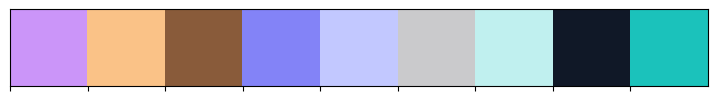

```python
sns.palplot(custom_palette)
plt.show()
```

[figure not shown]

I pulled the data from the US census.gov API for 2020-2024. It includes the total estimate of US Cocoa Bean Imports (weight in lbs, spend in $s), broken out by region/country:

Example URL:

https://api.census.gov/data/timeseries/intltrade/imports/enduse?get=CTY_CODE,CTY_NAME,I_ENDUSE,I_ENDUSE_LDESC,GEN_VAL_MO,CON_VAL_MO&I_ENDUSE=00010&YEAR=2013&MONTH=02

```python
base_url = "https://api.census.gov/data/timeseries/intltrade/imports/enduse"
get_fields = "CTY_CODE,CTY_NAME,I_ENDUSE,I_ENDUSE_LDESC,GEN_VAL_MO,CON_VAL_MO,AIR_WGT_MO,CNT_WGT_MO,VES_WGT_MO"
I_ENDUSE = "00010"
start_year = 2020
end_year = 2024
months = range(1, 13)

all_data = []

for year in range(start_year, end_year + 1):
    for month in months:
        time_str = f"{year}-{month:02}"
        url = f"{base_url}?get={get_fields}&I_ENDUSE={I_ENDUSE}&time={time_str}"
        response = requests.get(url)
        if response.status_code == 200:
            data = response.json()
            headers = data[0]
            values = data[1:]
            all_data.extend(values)
        else:
            print(f"Error fetching {time_str}: {response.status_code}")

df = pd.DataFrame(all_data, columns=headers)
print(df)
```

```
     CTY_CODE            CTY_NAME I_ENDUSE I_ENDUSE_LDESC GEN_VAL_MO  \
0        6040    PAPUA NEW GUINEA    00010    COCOA BEANS    1825500
1        2489             GRENADA    00010    COCOA BEANS       4172
2        3010            COLOMBIA    00010    COCOA BEANS     254616
3        3070           VENEZUELA    00010    COCOA BEANS     281799
4        3310             ECUADOR    00010    COCOA BEANS    9281115
...       ...                 ...      ...            ...        ...
3018     2470  DOMINICAN REPUBLIC    00010    COCOA BEANS    8116783
3019     7830            TANZANIA    00010    COCOA BEANS     105958
3020     7880          MADAGASCAR    00010    COCOA BEANS     142291
3021     2XXX     CENTRAL AMERICA    00010    COCOA BEANS    8116783
3022     3XXX       SOUTH AMERICA    00010    COCOA BEANS   77767295

     CON_VAL_MO AIR_WGT_MO CNT_WGT_MO VES_WGT_MO I_ENDUSE     time
0       1825500          0     731520     731520    00010  2020-01
1          4172       1090          0          0    00010  2020-01
2        254616          0      75950      75950    00010  2020-01
3        281799          0     113401     113401    00010  2020-01
4       9281115          0    3359617    3359617    00010  2020-01
...         ...        ...        ...        ...      ...      ...
3018    8116783          0    1086180    1086180    00010  2024-12
3019     105958          0      12826      12826    00010  2024-12
3020     142291        210      13219      13219    00010  2024-12
3021    8116783          0    1086180    1086180    00010  2024-12
3022   77767295       5188    9285205    9285205    00010  2024-12

[3023 rows x 11 columns]
```

```python
df.to_csv("us_cocoa_imports_2020_2024.csv", index=False)
```

Variables:

https://api.census.gov/data/timeseries/intltrade/imports/enduse/variables.html

Variable Dictionary:

```python
variable_dict = {
  "CTY_CODE": "Country Code",
  "CTY_NAME": "Country Name",
  "I_ENDUSE": "Import End Use Code",
  "I_ENDUSE_LDESC": "Import End Use Long Description",
  "GEN_VAL_MO": "General Imports Total Value",
  "CON_VAL_MO": "Imports for Consumption, Total Value",
  "AIR_WGT_MO": "Air Shipping Weight",
  "CNT_WGT_MO": "Containerized Vessel Shipping Weight",
  "VES_WGT_MO": "Vessel Shipping Weight"}
```

```python
print(tabulate(variable_dict.items(), headers=["Variable", "Description"]))
```

```
Variable        Description
--------------  ------------------------------------
CTY_CODE        Country Code
CTY_NAME        Country Name
I_ENDUSE        Import End Use Code
I_ENDUSE_LDESC  Import End Use Long Description
GEN_VAL_MO      General Imports Total Value
CON_VAL_MO      Imports for Consumption, Total Value
AIR_WGT_MO      Air Shipping Weight
CNT_WGT_MO      Containerized Vessel Shipping Weight
VES_WGT_MO      Vessel Shipping Weight
```

[figure not shown]

The data was complete and there were no missing values:

There are ~3K monthly records for the timeframe that I pulled.

```python
df.info()
```

```
<class 'pandas.core.frame.DataFrame'>
RangeIndex: 3023 entries, 0 to 3022
Data columns (total 11 columns):
 #   Column          Non-Null Count  Dtype
---  ------          --------------  -----
 0   CTY_CODE        3023 non-null   object
 1   CTY_NAME        3023 non-null   object
 2   I_ENDUSE        3023 non-null   object
 3   I_ENDUSE_LDESC  3023 non-null   object
 4   GEN_VAL_MO      3023 non-null   object
 5   CON_VAL_MO      3023 non-null   object
 6   AIR_WGT_MO      3023 non-null   object
 7   CNT_WGT_MO      3023 non-null   object
 8   VES_WGT_MO      3023 non-null   object
 9   I_ENDUSE        3023 non-null   object
 10  time            3023 non-null   object
dtypes: object(11)
memory usage: 259.9+ KB
```

Add "weight" variable, which is a combination of air, container, and vessel weights:

```python
df["Weight"] = df["AIR_WGT_MO"].astype(int) + df["CNT_WGT_MO"].astype(int) + df["VES_WGT_MO"].astype(int)
```

Drop unneeded variables (country codes, cocoa beans code & description, consumption value (vs. general value) - only used for consumption vs. for anything, individual weights:

```python
df.drop(columns=["CTY_CODE","I_ENDUSE","I_ENDUSE_LDESC","CON_VAL_MO","AIR_WGT_MO","CNT_WGT_MO","VES_WGT_MO"], inplace=True)
```

Rename country, spend, and month:

```python
df.rename(columns={'CTY_NAME':'Country'}, inplace=True)
df.rename(columns={'GEN_VAL_MO':'Spend'}, inplace=True)
df.rename(columns={'time':'Import Date'}, inplace=True)
```

Change datatypes:

```python
df['Import Date'] = pd.to_datetime(
    df['Import Date'],
    format='%Y-%m',
    errors='raise'
)
```

```python
df['Year'] = df['Import Date'].dt.year
```

```python
df['Month'] = df['Import Date'].dt.month
```

```python
df['Spend']=df['Spend'].astype(int)
```

Add field for price per pound:

```python
df['Price per Pound'] = df['Spend'] / df['Weight']
```

Field creation introducted NAs, fill NAs with 0:

```python
df['Price per Pound']=df['Price per Pound'].fillna(0)
```

View country names:

```python
df['Country'].unique()
```

```
array(['PAPUA NEW GUINEA', 'GRENADA', 'COLOMBIA', 'VENEZUELA', 'ECUADOR',
       'PERU', 'BRAZIL', 'FIJI', "COTE D'IVOIRE", 'GHANA',
       'DEMOCRATIC REPUBLIC OF THE CONGO', 'TOTAL FOR ALL COUNTRIES',
       'NORTH AMERICA', 'AFRICA', 'PACIFIC RIM COUNTRIES', 'CAFTA-DR',
       'AUSTRALIA AND OCEANIA', 'USMCA (NAFTA)',
       'TWENTY LATIN AMERICAN REPUBLICS', 'OECD', 'LAFTA', 'APEC', 'CACM',
       'MEXICO', 'GUATEMALA', 'COSTA RICA', 'DOMINICAN REPUBLIC',
       'TANZANIA', 'MADAGASCAR', 'CENTRAL AMERICA', 'SOUTH AMERICA',
       'CAMEROON', 'HAITI', 'INDIA', 'BOLIVIA', 'FRANCE', 'SWITZERLAND',
       'EUROPEAN UNION', 'EUROPE', 'ASIA', 'NATO', 'EURO AREA',
       'NICARAGUA', 'INDONESIA', 'PHILIPPINES', 'NIGERIA', 'CONGO',
       'ASEAN', 'NETHERLANDS', 'UGANDA', 'BELIZE', 'EL SALVADOR',
       'JAMAICA', 'TRINIDAD AND TOBAGO', 'HONDURAS', 'VIETNAM', 'TURKEY',
       'ITALY', 'CANADA', 'THAILAND', 'TOGO', 'BELGIUM', 'SIERRA LEONE',
       'MALAYSIA', 'GERMANY', 'CZECH REPUBLIC', 'PANAMA', 'SPAIN',
       'VANUATU', 'SAMOA'], dtype=object)
```

```python
df['Country'].nunique()
```

```
70
```

Identify groups of countries to remove, to keep only individual countries:

```python
groups_to_remove = [
    "TOTAL FOR ALL COUNTRIES", "USMCA (NAFTA)", "OECD", "LAFTA", "APEC",
    "CACM", "EUROPEAN UNION", "EUROPE","AFRICA", "ASIA", "NATO", "EURO AREA", "ASEAN", "SOUTH AMERICA",
    'CENTRAL AMERICA', 'NORTH AMERICA',
    'AUSTRALIA AND OCEANIA',
    'EUROPEAN UNION', 'EURO AREA', 'NATO','TWENTY LATIN AMERICAN REPUBLICS',
    'PACIFIC RIM COUNTRIES'
]

df = df[~df["Country"].isin(groups_to_remove)]
```

Assign continent group to countries:

```python
continent_map = {
    # Asia
    'INDONESIA': 'Asia', 'VIETNAM': 'Asia',
    'INDIA': 'Asia', 'THAILAND': 'Asia', 'PHILIPPINES': 'Asia', 'MALAYSIA': 'Asia',
    'TURKEY': 'Asia', #Turkey is 97% in Asia - 3% in Europe

    # Africa
    'CAMEROON': 'Africa', "COTE D'IVOIRE": 'Africa', 'GHANA': 'Africa', 'NIGERIA': 'Africa',
    'DEMOCRATIC REPUBLIC OF THE CONGO': 'Africa', 'CONGO': 'Africa', 'TANZANIA': 'Africa', 'UGANDA': 'Africa',
    'TOGO': 'Africa', 'SIERRA LEONE': 'Africa', 'MADAGASCAR': 'Africa',

    # Europe
    'NETHERLANDS': 'Europe', 'FRANCE': 'Europe', 'SWITZERLAND': 'Europe',
    'ITALY': 'Europe', 'BELGIUM': 'Europe', 'GERMANY': 'Europe', 'CZECH REPUBLIC': 'Europe', 'SPAIN': 'Europe',

    # North America
    'EL SALVADOR': 'North America', 'GRENADA': 'North America', 'PANAMA': 'North America',
    'CANADA': 'North America', 'MEXICO': 'North America', 'GUATEMALA': 'North America', 'HONDURAS': 'North America',
    'COSTA RICA': 'North America', 'HAITI': 'North America', 'DOMINICAN REPUBLIC': 'North America',
    'JAMAICA': 'North America',
    'TRINIDAD AND TOBAGO': 'North America', 'BELIZE': 'North America', 'NICARAGUA': 'North America',
    'CAFTA-DR': 'North America',

    # South America
    'ECUADOR': 'South America', 'PERU': 'South America', 'BRAZIL': 'South America', 'COLOMBIA': 'South America',
    'BOLIVIA': 'South America', 'VENEZUELA': 'South America',

    # Oceania
    'FIJI': 'Oceania', 'VANUATU': 'Oceania', 'SAMOA': 'Oceania', 'PAPUA NEW GUINEA': 'Oceania'

}

df['Continent'] = df['Country'].map(continent_map).fillna('Other')

print(df)
```

```
                 Country    Spend Import Date   Weight  Year  Month  \
0       PAPUA NEW GUINEA  1825500  2020-01-01  1463040  2020      1
1                GRENADA     4172  2020-01-01     1090  2020      1
2               COLOMBIA   254616  2020-01-01   151900  2020      1
3              VENEZUELA   281799  2020-01-01   226802  2020      1
4                ECUADOR  9281115  2020-01-01  6719234  2020      1
...                  ...      ...         ...      ...   ...    ...
3016          COSTA RICA        0  2024-12-01        0  2024     12
3017               HAITI        0  2024-12-01        0  2024     12
3018  DOMINICAN REPUBLIC  8116783  2024-12-01  2172360  2024     12
3019            TANZANIA   105958  2024-12-01    25652  2024     12
3020          MADAGASCAR   142291  2024-12-01    26648  2024     12

      Price per Pound      Continent
0            1.247744        Oceania
1            3.827523  North America
2            1.676208  South America
3            1.242489  South America
4            1.381276  South America
...               ...            ...
3016         0.000000  North America
3017         0.000000  North America
3018         3.736389  North America
3019         4.130594         Africa
3020         5.339650         Africa

[1906 rows x 8 columns]
```

```python
new_order = ['Continent','Country', 'Import Date', 'Month','Year', 'Weight', 'Price per Pound', 'Spend']

df = df[new_order]
```

```python
df.head()
```

|  | Continent | Country | Import Date | Month | Year | Weight | Price per Pound | Spend |
| --- | --- | --- | --- | --- | --- | --- | --- | --- |
| 0 | Oceania | PAPUA NEW GUINEA | 2020-01-01 | 1 | 2020 | 1463040 | 1.247744 | 1825500 |
| 1 | North America | GRENADA | 2020-01-01 | 1 | 2020 | 1090 | 3.827523 | 4172 |
| 2 | South America | COLOMBIA | 2020-01-01 | 1 | 2020 | 151900 | 1.676208 | 254616 |
| 3 | South America | VENEZUELA | 2020-01-01 | 1 | 2020 | 226802 | 1.242489 | 281799 |
| 4 | South America | ECUADOR | 2020-01-01 | 1 | 2020 | 6719234 | 1.381276 | 9281115 |

```python
df.info()
```

```
<class 'pandas.core.frame.DataFrame'>
Index: 1906 entries, 0 to 3020
Data columns (total 8 columns):
 #   Column           Non-Null Count  Dtype
---  ------           --------------  -----
 0   Continent        1906 non-null   object
 1   Country          1906 non-null   object
 2   Import Date      1906 non-null   datetime64[ns]
 3   Month            1906 non-null   int32
 4   Year             1906 non-null   int32
 5   Weight           1906 non-null   int64
 6   Price per Pound  1906 non-null   float64
 7   Spend            1906 non-null   int64
dtypes: datetime64[ns](1), float64(1), int32(2), int64(2), object(2)
memory usage: 119.1+ KB
```

```python
df['Country'].nunique()
```

```
51
```

[figure not shown]

Total US Cocoa Bean Imports | Spend by Year:

Spend in 2024 (1.2B) was a close 2nd to the highest which was in 2021 (1.3B):

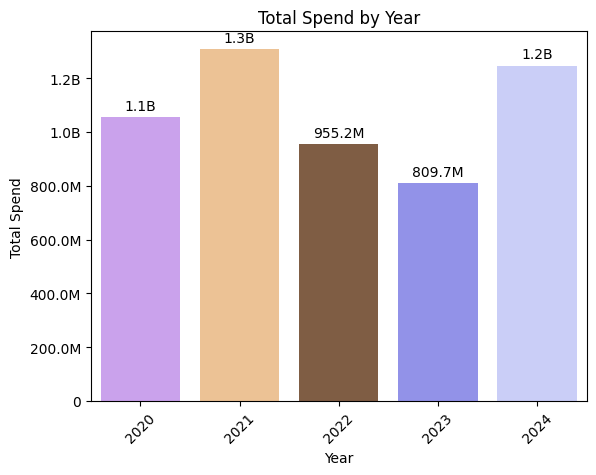

```python
spend_by_year = df.groupby(['Year'])['Spend'].sum().reset_index()

def axis_format(x, pos=None):
    if x >= 1e12:
        return f'{x/1e12:.1f}T'
    elif x >= 1e9:
        return f'{x/1e9:.1f}B'
    elif x >= 1e6:
        return f'{x/1e6:.1f}M'
    else:
        return f'{x:.0f}'

ax = sns.barplot(
    data=spend_by_year,
    x='Year',
    y='Spend',
    hue='Year',
    palette=custom_palette[:5],
    legend=False
)

for container in ax.containers:
    labels = [axis_format(v) for v in container.datavalues]
    ax.bar_label(container, labels=labels, padding=3)

ax.yaxis.set_major_formatter(mtick.FuncFormatter(axis_format))

plt.title('Total Spend by Year')
plt.ylabel('Total Spend')
plt.xlabel('Year')
plt.xticks(rotation=45)
plt.show()
```

Although spend was high, it was due to high prices. The volume (weight) actually had been trending down and was at the lowest in 5 years:

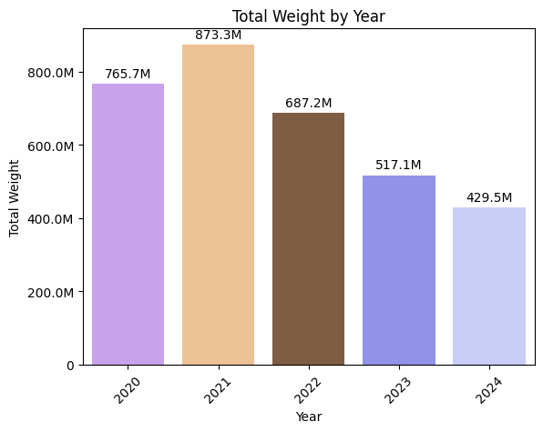

```python
weight_by_year = df.groupby(['Year'])['Weight'].sum().reset_index()

def axis_format(x, pos=None):
    if x >= 1e12:
        return f'{x/1e12:.1f}T'
    elif x >= 1e9:
        return f'{x/1e9:.1f}B'
    elif x >= 1e6:
        return f'{x/1e6:.1f}M'
    else:
        return f'{x:.0f}'

ax = sns.barplot(
    data=weight_by_year,
    x='Year',
    y='Weight',
    hue='Year',
    palette=custom_palette[:5],
    legend=False
)

for container in ax.containers:
    labels = [axis_format(v) for v in container.datavalues]
    ax.bar_label(container, labels=labels, padding=3)

ax.yaxis.set_major_formatter(mtick.FuncFormatter(axis_format))

plt.title('Total Weight by Year')
plt.ylabel('Total Weight')
plt.xlabel('Year')
plt.xticks(rotation=45)
plt.show()
```

Monthly aggregated chart of Spend, Price per Pound, & Weight:

```python
monthly_df = (
    df
    .groupby('Import Date', as_index=False)
    .agg({
        'Weight': 'sum',
        'Spend': 'sum'
    })
)

monthly_df['Price per Pound'] = monthly_df['Spend'] / monthly_df['Weight']
monthly_df['Year'] = monthly_df['Import Date'].dt.year
monthly_df['Month'] = monthly_df['Import Date'].dt.strftime('%b')
```

```python
monthly_df.head()
```

|  | Import Date | Weight | Spend | Price per Pound | Year | Month |
| --- | --- | --- | --- | --- | --- | --- |
| 0 | 2020-01-01 | 77863938 | 110827113 | 1.423343 | 2020 | Jan |
| 1 | 2020-02-01 | 118967413 | 183396139 | 1.541566 | 2020 | Feb |
| 2 | 2020-03-01 | 117594405 | 160633331 | 1.365995 | 2020 | Mar |
| 3 | 2020-04-01 | 72523979 | 109295892 | 1.507031 | 2020 | Apr |
| 4 | 2020-05-01 | 58180114 | 71059481 | 1.221371 | 2020 | May |

US Cocoa Bean Imports YOY | Spend:

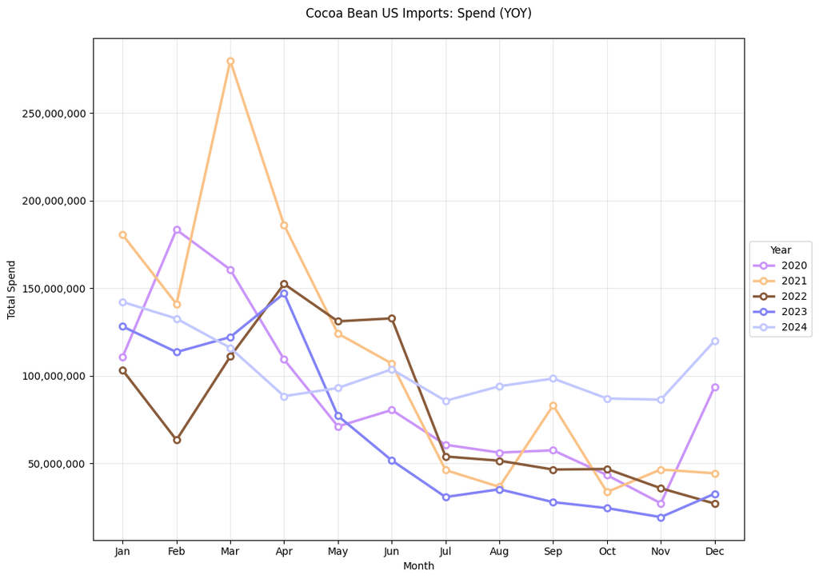

```python
plt.figure(figsize=(12, 8))

for i, year in enumerate(monthly_df['Year'].unique()):
    year_data = monthly_df[monthly_df['Year'] == year]
    plt.plot(year_data['Month'], year_data['Spend'],
             marker='o', linewidth=2.5, markersize=6,
             color=custom_palette[i % len(custom_palette)],
             label=str(year), markerfacecolor='white',
             markeredgewidth=2)

plt.gca().yaxis.set_major_formatter(ticker.StrMethodFormatter('{x:,.0f}'))
plt.title('Cocoa Bean US Imports: Spend (YOY)', pad=20)
plt.xlabel('Month')
plt.ylabel('Total Spend')
plt.legend(title='Year', loc='center left', bbox_to_anchor=(1, 0.5))
plt.grid(True, alpha=0.3)
plt.tight_layout()
plt.subplots_adjust(right=0.85)
plt.show()
```

US Cocoa Bean Imports YOY | Price per Pound:

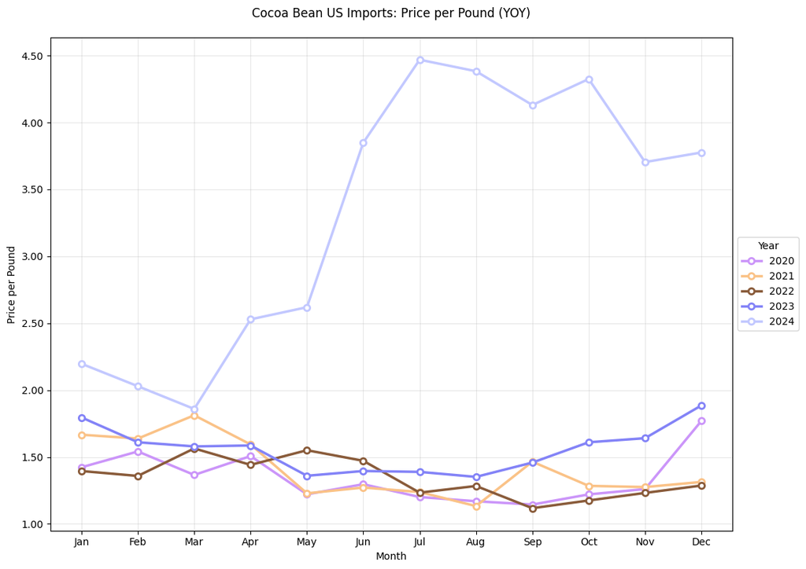

```python
plt.figure(figsize=(12, 8))

for i, year in enumerate(monthly_df['Year'].unique()):
    year_data = monthly_df[monthly_df['Year'] == year]
    plt.plot(year_data['Month'], year_data['Price per Pound'],
             marker='o', linewidth=2.5, markersize=6,
             color=custom_palette[i % len(custom_palette)],
             label=str(year), markerfacecolor='white',
             markeredgewidth=2)

plt.gca().yaxis.set_major_formatter(ticker.StrMethodFormatter('{x:,.2f}'))
plt.title('Cocoa Bean US Imports: Price per Pound (YOY)', pad=20)
plt.xlabel('Month')
plt.ylabel('Price per Pound')
plt.legend(title='Year', loc='center left', bbox_to_anchor=(1, 0.5))
plt.grid(True, alpha=0.3)
plt.tight_layout()
plt.subplots_adjust(right=0.85)
plt.show()
```

US Cocoa Bean Imports YOY | Weight:

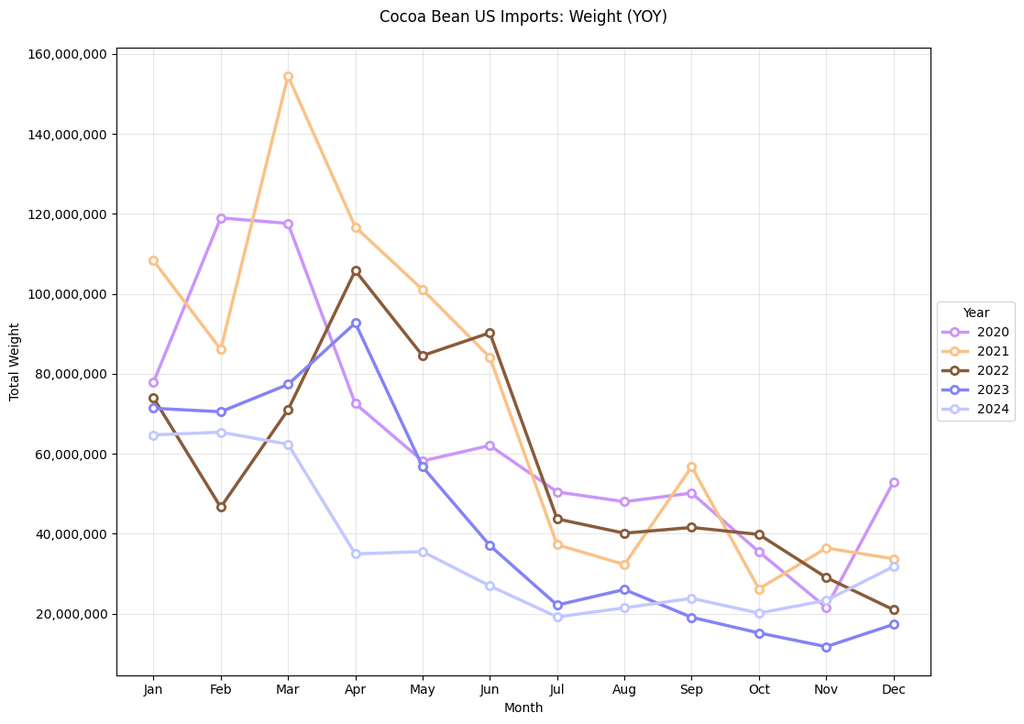

```python
plt.figure(figsize=(12, 8))

for i, year in enumerate(monthly_df['Year'].unique()):
    year_data = monthly_df[monthly_df['Year'] == year]
    plt.plot(year_data['Month'], year_data['Weight'],
             marker='o', linewidth=2.5, markersize=6,
             color=custom_palette[i % len(custom_palette)],
             label=str(year), markerfacecolor='white',
             markeredgewidth=2)
plt.gca().yaxis.set_major_formatter(ticker.StrMethodFormatter('{x:,.0f}'))
plt.title('Cocoa Bean US Imports: Weight (YOY)', pad=20)
plt.xlabel('Month')
plt.ylabel('Total Weight')
plt.legend(title='Year', loc='center left', bbox_to_anchor=(1, 0.5))
plt.grid(True, alpha=0.3)
plt.tight_layout()
plt.subplots_adjust(right=0.85)
plt.show()
```

[figure not shown]

I first performed decomposition on the data to get an idea of its components (trend, seasonality, residuals):

Run sequence plots:

These charts are continuous time series that show the pattern of the data in one sequence (vs. YOY, etc.). They are a good visual to see if there is a trend, seasonality, etc.

```python
def run_sequence_plot(x, y, title, xlabel="time", ylabel="series", width=13, height=4):
    plt.figure(figsize=(width, height))
    plt.plot(x, y, 'k-')
    plt.title(title)
    plt.xlabel(xlabel)
    plt.ylabel(ylabel)
    plt.grid(alpha=0.3)
    plt.show()
```

The Weight and Spend show strong seasonal patterns:

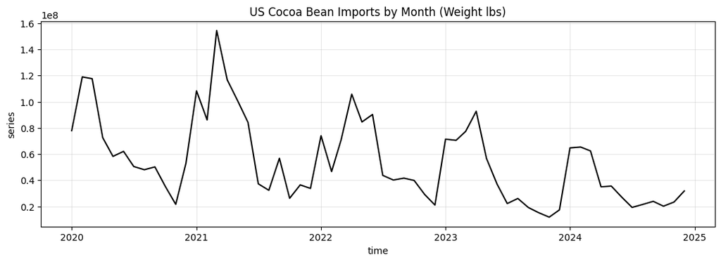

```python
run_sequence_plot(monthly_df['Import Date'], monthly_df['Weight'],
                  title="US Cocoa Bean Imports by Month (Weight lbs)")
```

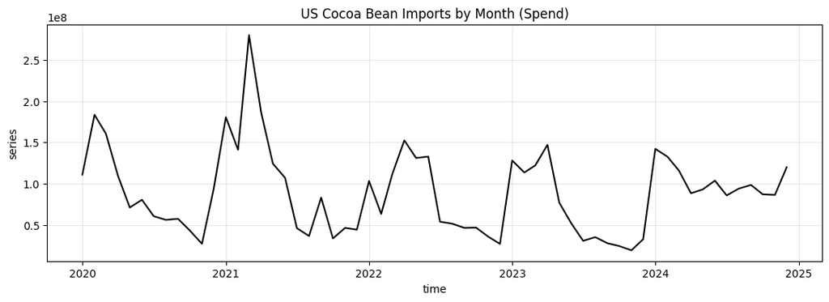

```python
run_sequence_plot(monthly_df['Import Date'], monthly_df['Spend'],
                  title="US Cocoa Bean Imports by Month (Spend)")
```

The Price shows a strong upward trend:

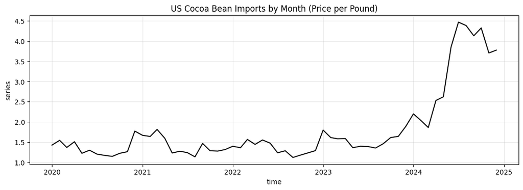

```python
run_sequence_plot( monthly_df['Import Date'],  monthly_df['Price per Pound'],
                  title="US Cocoa Bean Imports by Month (Price per Pound)")
```

Transformations (to remove trend and seasonality):

Full decomposition for Weight (breaks out run sequence, trend, seasonality, residuals):

```python
data = monthly_df.set_index('Import Date')['Weight']
```

```python
display(data.head())
```

```
Import Date
2020-01-01     77863938
2020-02-01    118967413
2020-03-01    117594405
2020-04-01     72523979
2020-05-01     58180114
Name: Weight, dtype: int64
```

Period: 12 for yearly seasonality:

```python
ss_decomposition = seasonal_decompose(x=data, model='additive', period=12)
estimated_trend = ss_decomposition.trend
estimated_seasonal = ss_decomposition.seasonal
estimated_residual = ss_decomposition.resid
```

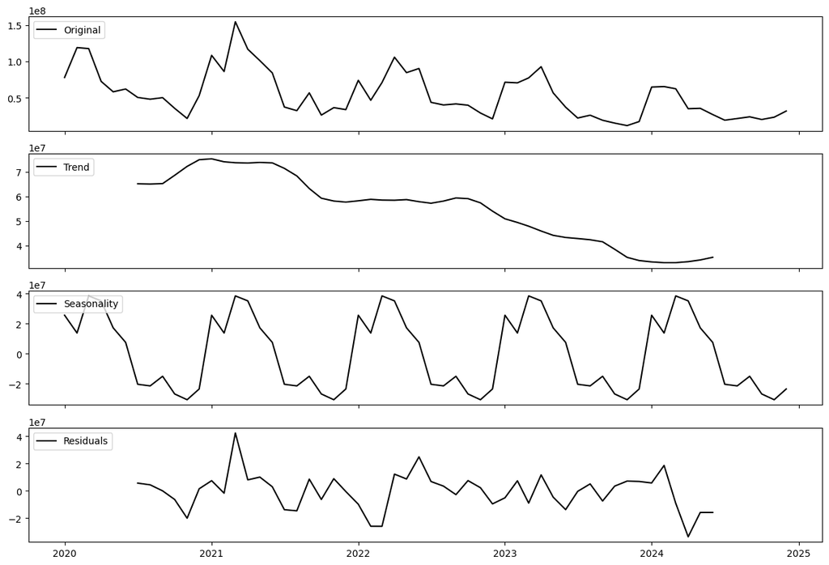

```python
fig, axes = plt.subplots(4, 1, sharex=True, sharey=False)
fig.set_figheight(10)
fig.set_figwidth(15)

axes[0].plot(data, label='Original', color='black')
axes[0].legend(loc='upper left')

axes[1].plot(estimated_trend, label='Trend', color='black')
axes[1].legend(loc='upper left')

axes[2].plot(estimated_seasonal, label='Seasonality', color='black')
axes[2].legend(loc='upper left')

axes[3].plot(estimated_residual, label='Residuals', color='black')
axes[3].legend(loc='upper left')
```

(The first chart in the group is the run sequence again)

Trend: The trend would be an increasing or decreasing slope over time (upward vs. downward). This shows a downward trend in cocoa bean imports over time.

Seasonality: Seasonality would be repeated, periodic patterns over time. This chart shows that for the most part there are peaks at the beginning of each year for cocoa bean imports and it drops throughout the year.

Residuals: The left-over fluctuations after removing the trend & seasonality, These appear pretty random and uncorrelated for the most part. When they are random, correlated, normally distributed and have a mean around 0, it means that the trend and seasonality have effectively been identified and removed from the data. Here the mean is around 0, and there is no trend or seasonality left and the mean is constant.

Plotting the residuals in a histograms shows that they roughly follow a normal distribution:

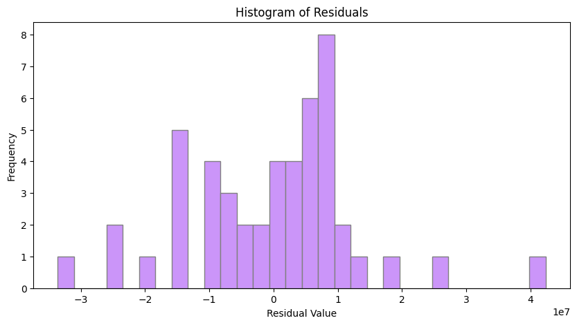

```python
plt.figure(figsize=(10, 5))
plt.hist(estimated_residual, bins=30, color=custom_palette[0], edgecolor='gray')
plt.title('Histogram of Residuals')
plt.xlabel('Residual Value')
plt.ylabel('Frequency')
plt.show()
```

The first and last 6 values of the residuals are NaN and are removed:

```python
print(estimated_residual[-6:])
```

```
Import Date
2024-07-01   NaN
2024-08-01   NaN
2024-09-01   NaN
2024-10-01   NaN
2024-11-01   NaN
2024-12-01   NaN
Name: resid, dtype: float64
```

```python
print(estimated_residual[:6])
```

```
Import Date
2020-01-01   NaN
2020-02-01   NaN
2020-03-01   NaN
2020-04-01   NaN
2020-05-01   NaN
2020-06-01   NaN
Name: resid, dtype: float64
```

(Ignore Lag 0: always shows up and is equal to 1 because lags are a correlation with the current value, and 0 is the current value, so it will be 1)

Lags 1-2: means that the values for today are correlated to those for last month, & 2 months ago. Lag 12: means the values for today are correlated to those from 12 months ago. High autocorrelation at smaller lags and slow decay is representative of a trend.

I plotted 24 lags to see if there is a seasonality cycle longer than 12, but there is not. 12 is the last significant lag, so the period for the decomposition should remain at 12 for annual seasonality.

Lags 1, 2 & 12 are significant for autocorrelation, but looking at the partial autocorrelation where it removes the dependence on the previous lag, only 1 and 12 are significant, showing that the current value is correlated with the previous value (AR1) and the value 12 months ago (seasonal AR term since data is monthly).

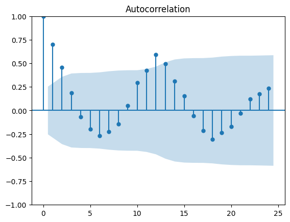

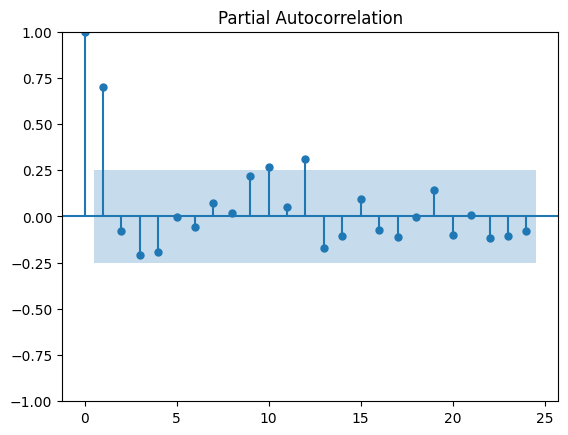

```python
plot_acf(data, lags=24)
plot_pacf(data, lags=24)
plt.show()
```

```python
residuals_final = estimated_residual[6:-6]
#same as estimated_residual.dropna()
```

Residuals show autocorrelation at lag 4, which I gave the option to be modeled in SARIMA later (turned stepwise off and allowed it to go up to 4) but a model including this lag was not the best performer, so this effect was not as important:

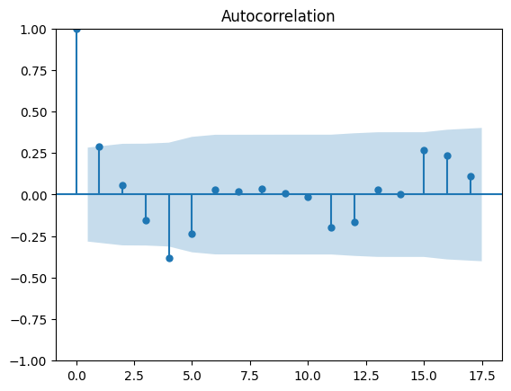

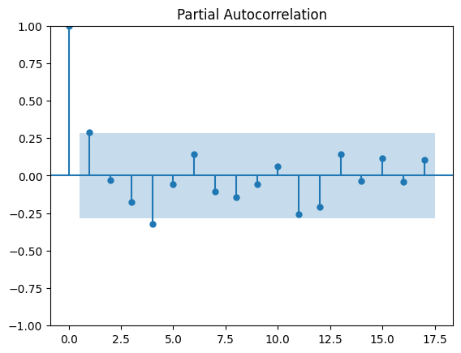

```python
plot_acf(residuals_final)
plot_pacf(residuals_final)
plt.show()
```

The Dickey Fuller Test confirms the original data is non-stationary as we cannot reject the null that the data is non-stationary:

(Stationary data would have constant mean & variance, no autocorrelation, and no periodic component)

```python
adf_b4, pvalue_b4, usedlag_, nobs_, critical_values_, icbest_ = adfuller(data)
print(f"ADF: {adf_b4:.6f}")
print(f"p-value: {pvalue_b4:.9f}")
```

```
ADF: 0.021728
p-value: 0.960292504
```

Test the residuals for stationarity (after removing 1st and last 6 values since they're NaN):

After removing the trend and seasonality, the residuals are stationary (p-value <0.05) and no further differencing is needed, therefore this decomposition adquately captures the patterns in the data as a good way to understand it:

```python
adf_b4, pvalue_b4, usedlag_, nobs_, critical_values_, icbest_ = adfuller(residuals_final)
print(f"ADF: {adf_b4:.6f}")
print(f"p-value: {pvalue_b4:.9f}")
```

```
ADF: -4.862790
p-value: 0.000041182
```

[figure not shown]

## Model 1: Smoothing

I first performed Smoothing as a model option/baseline. I chose Triple Exponential Smoothing, as that is the best option when there is both trend and seasonality.

Smoothing calculates a moving average in order to reduce noise. Exponential Smoothing weights the more recent lags more heavily. Triple Exponential Smoothing includes 3 components to smooth the value, the trend, and the seasonality.

```python
monthly_df.head()
```

|  | Import Date | Weight | Spend | Price per Pound | Year | Month |
| --- | --- | --- | --- | --- | --- | --- |
| 0 | 2020-01-01 | 77863938 | 110827113 | 1.423343 | 2020 | Jan |
| 1 | 2020-02-01 | 118967413 | 183396139 | 1.541566 | 2020 | Feb |
| 2 | 2020-03-01 | 117594405 | 160633331 | 1.365995 | 2020 | Mar |
| 3 | 2020-04-01 | 72523979 | 109295892 | 1.507031 | 2020 | Apr |
| 4 | 2020-05-01 | 58180114 | 71059481 | 1.221371 | 2020 | May |

```python
data = pd.DataFrame({
    'Import Date': monthly_df['Import Date'],
    'Weight': monthly_df['Weight']
})
```

```python
data.head()
```

|  | Import Date | Weight |
| --- | --- | --- |
| 0 | 2020-01-01 | 77863938 |
| 1 | 2020-02-01 | 118967413 |
| 2 | 2020-03-01 | 117594405 |
| 3 | 2020-04-01 | 72523979 |
| 4 | 2020-05-01 | 58180114 |

```python
train = data[:-5]
test = data[-5:]
```

```python
triple = ExponentialSmoothing(train['Weight'],
                              trend="additive",damped_trend=True,
                              seasonal="additive",
                              seasonal_periods=12).fit(optimized=True)
triple_preds = triple.forecast(len(test['Weight']))
```

The untuned Exponential Smoothing performs very poorly, greatly overestimating the downward trend:

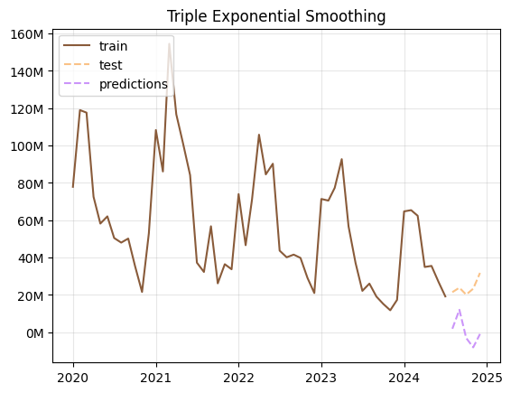

```python
plt.plot(train['Import Date'], train['Weight'], color=custom_palette[2], label="train")
plt.plot(test['Import Date'], test['Weight'], color=custom_palette[1], linestyle="--", label="test")
plt.plot(test['Import Date'], triple_preds, color=custom_palette[0], linestyle="--", label="predictions")

def millions(x, pos):
    return f'{int(x/1e6)}M'

plt.gca().yaxis.set_major_formatter(FuncFormatter(millions))

plt.legend(loc='upper left')
plt.title("Triple Exponential Smoothing")
plt.grid(alpha=0.3)
plt.show()
```

Below is a Rolling CV for the model. It forecasts a 3 month horizon (add one month, predict 3 month out, add another month, predict again, etc.) starting with a cutoff of 45 months (Sep '23) and predicting through the 60th month of data (Dec '24):

Reported are the forecast vs. actual (yhat vs. y) and the absolute error (difference btw those two) and the absolute percentage error (error/actual):

```python
horizon = 3
exp_ts_results = []

for cutoff in range(44, 60):
    if cutoff + horizon >= len(data):
        break

    train_series = data['Weight'].iloc[:cutoff + 1]

    triple = ExponentialSmoothing(
        train_series,
        trend="additive", damped_trend=True,
        seasonal="additive", seasonal_periods=12
    ).fit(optimized=True)

    yhat = triple.forecast(steps=horizon)
    y_true = data['Weight'].iloc[cutoff + 1 : cutoff + 1 + horizon]

    for h in range(horizon):
        ae = abs(yhat.iloc[h] - y_true.iloc[h])
        ape = ae / max(abs(y_true.iloc[h]), 1e-8)

        exp_ts_results.append({
            'cutoff': cutoff,
            'horizon': h + 1,
            'cutoff_month': data['Import Date'].iloc[cutoff].to_period('M').to_timestamp(),
            'month': data['Import Date'].iloc[cutoff + h + 1].to_period('M').to_timestamp(),
            'y': y_true.iloc[h],
            'yhat': yhat.iloc[h],
            'AE': ae,
            'APE': ape
        })

exp_ts_cv_df = pd.DataFrame(exp_ts_results)

exp_ts_cv_df.style.format({
    'cutoff_month': '{:%m-%d-%Y}',
    'month': '{:%m-%d-%Y}',
    'y': '{:,.0f}',
    'yhat': '{:,.0f}',
    'AE': '{:,.0f}',
    'APE': '{:.0%}'
})
```

|  | cutoff | horizon | cutoff_month | month | y | yhat | AE | APE |
| --- | --- | --- | --- | --- | --- | --- | --- | --- |
| 0 | 44 | 1 | 09-01-2023 | 10-01-2023 | 15,172,388 | 6,902,291 | 8,270,097 | 55% |
| 1 | 44 | 2 | 09-01-2023 | 11-01-2023 | 11,741,002 | 3,755,247 | 7,985,755 | 68% |
| 2 | 44 | 3 | 09-01-2023 | 12-01-2023 | 17,305,596 | 16,758,376 | 547,220 | 3% |
| 3 | 45 | 1 | 10-01-2023 | 11-01-2023 | 11,741,002 | 6,045,882 | 5,695,120 | 49% |
| 4 | 45 | 2 | 10-01-2023 | 12-01-2023 | 17,305,596 | 19,019,260 | 1,713,664 | 10% |
| 5 | 45 | 3 | 10-01-2023 | 01-01-2024 | 64,702,033 | 66,344,501 | 1,642,468 | 3% |
| 6 | 46 | 1 | 11-01-2023 | 12-01-2023 | 17,305,596 | 20,419,934 | 3,114,338 | 18% |
| 7 | 46 | 2 | 11-01-2023 | 01-01-2024 | 64,702,033 | 67,744,089 | 3,042,056 | 5% |
| 8 | 46 | 3 | 11-01-2023 | 02-01-2024 | 65,375,575 | 44,310,438 | 21,065,137 | 32% |
| 9 | 47 | 1 | 12-01-2023 | 01-01-2024 | 64,702,033 | 65,781,660 | 1,079,627 | 2% |
| 10 | 47 | 2 | 12-01-2023 | 02-01-2024 | 65,375,575 | 49,667,363 | 15,708,212 | 24% |
| 11 | 47 | 3 | 12-01-2023 | 03-01-2024 | 62,364,919 | 83,586,898 | 21,221,979 | 34% |
| 12 | 48 | 1 | 01-01-2024 | 02-01-2024 | 65,375,575 | 49,337,538 | 16,038,037 | 25% |
| 13 | 48 | 2 | 01-01-2024 | 03-01-2024 | 62,364,919 | 83,257,077 | 20,892,158 | 33% |
| 14 | 48 | 3 | 01-01-2024 | 04-01-2024 | 34,933,233 | 88,121,981 | 53,188,748 | 152% |
| 15 | 49 | 1 | 02-01-2024 | 03-01-2024 | 62,364,919 | 88,140,823 | 25,775,904 | 41% |
| 16 | 49 | 2 | 02-01-2024 | 04-01-2024 | 34,933,233 | 93,005,732 | 58,072,499 | 166% |
| 17 | 49 | 3 | 02-01-2024 | 05-01-2024 | 35,504,037 | 69,119,308 | 33,615,271 | 95% |
| 18 | 50 | 1 | 03-01-2024 | 04-01-2024 | 34,933,233 | 85,707,057 | 50,773,824 | 145% |
| 19 | 50 | 2 | 03-01-2024 | 05-01-2024 | 35,504,037 | 61,820,637 | 26,316,600 | 74% |
| 20 | 50 | 3 | 03-01-2024 | 06-01-2024 | 26,935,635 | 52,160,066 | 25,224,431 | 94% |
| 21 | 51 | 1 | 04-01-2024 | 05-01-2024 | 35,504,037 | 43,120,813 | 7,616,776 | 21% |
| 22 | 51 | 2 | 04-01-2024 | 06-01-2024 | 26,935,635 | 33,690,321 | 6,754,686 | 25% |
| 23 | 51 | 3 | 04-01-2024 | 07-01-2024 | 19,175,494 | 854,284 | 18,321,210 | 96% |
| 24 | 52 | 1 | 05-01-2024 | 06-01-2024 | 26,935,635 | 29,169,740 | 2,234,105 | 8% |
| 25 | 52 | 2 | 05-01-2024 | 07-01-2024 | 19,175,494 | -3,643,501 | 22,818,995 | 119% |
| 26 | 52 | 3 | 05-01-2024 | 08-01-2024 | 21,449,146 | -6,523,088 | 27,972,234 | 130% |
| 27 | 53 | 1 | 06-01-2024 | 07-01-2024 | 19,175,494 | -4,737,622 | 23,913,116 | 125% |
| 28 | 53 | 2 | 06-01-2024 | 08-01-2024 | 21,449,146 | -7,620,189 | 29,069,335 | 136% |
| 29 | 53 | 3 | 06-01-2024 | 09-01-2024 | 23,828,291 | 2,650,308 | 21,177,983 | 89% |
| 30 | 54 | 1 | 07-01-2024 | 08-01-2024 | 21,449,146 | 1,861,780 | 19,587,366 | 91% |
| 31 | 54 | 2 | 07-01-2024 | 09-01-2024 | 23,828,291 | 12,006,067 | 11,822,224 | 50% |
| 32 | 54 | 3 | 07-01-2024 | 10-01-2024 | 20,121,692 | -3,091,509 | 23,213,201 | 115% |
| 33 | 55 | 1 | 08-01-2024 | 09-01-2024 | 23,828,291 | 23,815,662 | 12,629 | 0% |
| 34 | 55 | 2 | 08-01-2024 | 10-01-2024 | 20,121,692 | 9,571,620 | 10,550,072 | 52% |
| 35 | 55 | 3 | 08-01-2024 | 11-01-2024 | 23,311,088 | 5,205,149 | 18,105,939 | 78% |
| 36 | 56 | 1 | 09-01-2024 | 10-01-2024 | 20,121,692 | 9,577,936 | 10,543,756 | 52% |
| 37 | 56 | 2 | 09-01-2024 | 11-01-2024 | 23,311,088 | 5,211,465 | 18,099,623 | 78% |
| 38 | 56 | 3 | 09-01-2024 | 12-01-2024 | 31,759,202 | 12,984,396 | 18,774,806 | 59% |

The MAPEs (mean absolute percentage error) are very high and increase from the one month out prediction to the 3 month out prediction:

```python
exp_ts_cv = exp_ts_cv_df.groupby('horizon').agg(
    MAE=('AE', 'mean'),
    MAPE=('APE', 'mean'))

exp_ts_cv.style.format({
    'MAE': '{:,.0f}',
    'MAPE': '{:.0%}'})
```

| horizon | MAE | MAPE |
| --- | --- | --- |
| 1 | 13,434,977 | 49% |
| 2 | 17,911,221 | 65% |
| 3 | 21,851,587 | 75% |

```python
exp_ts_overall_MAE  = exp_ts_cv_df['AE'].mean()
exp_ts_overall_MAPE = exp_ts_cv_df['APE'].mean()

print(f"MAE: {exp_ts_overall_MAE:,.0f}")
print(f"MAPE (%): {exp_ts_overall_MAPE:.0%}")
```

```
MAE: 17,732,595
MAPE (%): 63%
```

Plot forecast (yhat) vs. actuals (y) for ALL data (not just a train/test split like above) to see model fit:

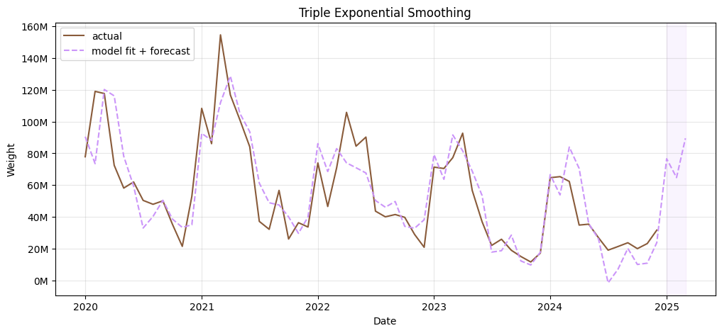

```python
triple = ExponentialSmoothing(
    data['Weight'],
    trend="additive", damped_trend=True,
    seasonal="additive", seasonal_periods=12
).fit(optimized=True)

fitted = triple.fittedvalues

forecast_steps = 3
forecast = triple.forecast(steps=forecast_steps)

last_date = data['Import Date'].iloc[-1]
future_dates = pd.date_range(
    start=last_date + pd.offsets.MonthBegin(1),
    periods=forecast_steps,
    freq='MS'
)

combined_preds = np.concatenate([fitted.values, forecast.values])
combined_dates = pd.concat([data['Import Date'], pd.Series(future_dates)], ignore_index=True)

plt.figure(figsize=(12, 5))

plt.plot(data['Import Date'], data['Weight'], color=custom_palette[2], label="actual")

plt.plot(combined_dates, combined_preds, color=custom_palette[0], linestyle='--', label="model fit + forecast")

plt.axvspan(future_dates[0], future_dates[-1], color=custom_palette[0], alpha=0.1)

plt.gca().yaxis.set_major_formatter(FuncFormatter(lambda x, pos: f'{int(x/1e6)}M'))

plt.legend(loc='upper left')
plt.title("Triple Exponential Smoothing")
plt.xlabel("Date")
plt.ylabel("Weight")
plt.grid(alpha=0.3)
plt.show()
```

I moved to tuning the Triple Exponential Smoothing by making the seasonality multiplicative. It does look like it has a fair multiplicative effect in that the seasonality jumps look like they decrease in magnitude with time. This adjustment does improve the model greatly:

```python
triple_tuned = ExponentialSmoothing(train['Weight'],
                              trend="additive",damped_trend=True,
                              seasonal="multiplicative",
                              seasonal_periods=12).fit(optimized=True)
triple_tuned_preds = triple_tuned.forecast(len(test['Weight']))
```

The forecast for the last 3 months greatly improves vs. the previous untuned version:

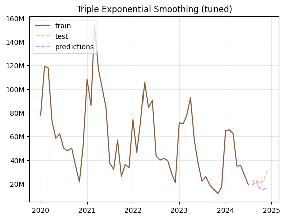

```python
plt.plot(train['Import Date'], train['Weight'], color=custom_palette[2], label="train")
plt.plot(test['Import Date'], test['Weight'], color=custom_palette[1], linestyle="--", label="test")
plt.plot(test['Import Date'], triple_tuned_preds, color=custom_palette[0], linestyle="--", label="predictions")

def millions(x, pos):
    return f'{int(x/1e6)}M'

plt.gca().yaxis.set_major_formatter(FuncFormatter(millions))

plt.legend(loc='upper left')
plt.title("Triple Exponential Smoothing (tuned)")
plt.grid(alpha=0.3)
plt.show()
```

```python
horizon = 3
exp_ts_tuned_results = []

for cutoff in range(44, 60):
    if cutoff + horizon >= len(data):
        break

    train = data['Weight'].iloc[:cutoff + 1]

    triple_tuned = ExponentialSmoothing(
        train,
        trend="additive", damped_trend=True,
        seasonal="multiplicative", seasonal_periods=12
    ).fit(optimized=True)

    yhat = triple_tuned.forecast(steps=horizon)
    y_true = data['Weight'].iloc[cutoff + 1 : cutoff + 1 + horizon]

    for h in range(horizon):
        ae = abs(yhat.iloc[h] - y_true.iloc[h])
        ape = ae / max(abs(y_true.iloc[h]), 1e-8)

        exp_ts_tuned_results.append({
            'cutoff': cutoff,
            'horizon': h + 1,
            'cutoff_month': data['Import Date'].iloc[cutoff].to_period('M').to_timestamp(),
            'month': data['Import Date'].iloc[cutoff + h + 1].to_period('M').to_timestamp(),
            'y': y_true.iloc[h],
            'yhat': yhat.iloc[h],
            'AE': ae,
            'APE': ape
        })

exp_ts_tuned_cv_df = pd.DataFrame(exp_ts_tuned_results)
exp_ts_tuned_cv_df.style.format({
    'cutoff_month': '{:%m-%d-%Y}',
    'month': '{:%m-%d-%Y}',
    'y': '{:,.0f}',
    'yhat': '{:,.0f}',
    'AE': '{:,.0f}',
    'APE': '{:.0%}'
})
```

|  | cutoff | horizon | cutoff_month | month | y | yhat | AE | APE |
| --- | --- | --- | --- | --- | --- | --- | --- | --- |
| 0 | 44 | 1 | 09-01-2023 | 10-01-2023 | 15,172,388 | 19,758,979 | 4,586,591 | 30% |
| 1 | 44 | 2 | 09-01-2023 | 11-01-2023 | 11,741,002 | 18,827,434 | 7,086,432 | 60% |
| 2 | 44 | 3 | 09-01-2023 | 12-01-2023 | 17,305,596 | 20,571,930 | 3,266,334 | 19% |
| 3 | 45 | 1 | 10-01-2023 | 11-01-2023 | 11,741,002 | 17,314,661 | 5,573,659 | 47% |
| 4 | 45 | 2 | 10-01-2023 | 12-01-2023 | 17,305,596 | 18,983,433 | 1,677,837 | 10% |
| 5 | 45 | 3 | 10-01-2023 | 01-01-2024 | 64,702,033 | 44,986,142 | 19,715,891 | 30% |
| 6 | 46 | 1 | 11-01-2023 | 12-01-2023 | 17,305,596 | 16,869,278 | 436,318 | 3% |
| 7 | 46 | 2 | 11-01-2023 | 01-01-2024 | 64,702,033 | 39,890,376 | 24,811,657 | 38% |
| 8 | 46 | 3 | 11-01-2023 | 02-01-2024 | 65,375,575 | 39,351,743 | 26,023,832 | 40% |
| 9 | 47 | 1 | 12-01-2023 | 01-01-2024 | 64,702,033 | 40,252,571 | 24,449,462 | 38% |
| 10 | 47 | 2 | 12-01-2023 | 02-01-2024 | 65,375,575 | 39,708,749 | 25,666,826 | 39% |
| 11 | 47 | 3 | 12-01-2023 | 03-01-2024 | 62,364,919 | 52,317,225 | 10,047,694 | 16% |
| 12 | 48 | 1 | 01-01-2024 | 02-01-2024 | 65,375,575 | 47,579,349 | 17,796,226 | 27% |
| 13 | 48 | 2 | 01-01-2024 | 03-01-2024 | 62,364,919 | 62,858,839 | 493,920 | 1% |
| 14 | 48 | 3 | 01-01-2024 | 04-01-2024 | 34,933,233 | 54,889,734 | 19,956,501 | 57% |
| 15 | 49 | 1 | 02-01-2024 | 03-01-2024 | 62,364,919 | 70,265,094 | 7,900,175 | 13% |
| 16 | 49 | 2 | 02-01-2024 | 04-01-2024 | 34,933,233 | 61,276,429 | 26,343,196 | 75% |
| 17 | 49 | 3 | 02-01-2024 | 05-01-2024 | 35,504,037 | 49,089,874 | 13,585,837 | 38% |
| 18 | 50 | 1 | 03-01-2024 | 04-01-2024 | 34,933,233 | 59,021,731 | 24,088,498 | 69% |
| 19 | 50 | 2 | 03-01-2024 | 05-01-2024 | 35,504,037 | 47,261,433 | 11,757,396 | 33% |
| 20 | 50 | 3 | 03-01-2024 | 06-01-2024 | 26,935,635 | 43,538,778 | 16,603,143 | 62% |
| 21 | 51 | 1 | 04-01-2024 | 05-01-2024 | 35,504,037 | 41,299,719 | 5,795,682 | 16% |
| 22 | 51 | 2 | 04-01-2024 | 06-01-2024 | 26,935,635 | 38,068,462 | 11,132,827 | 41% |
| 23 | 51 | 3 | 04-01-2024 | 07-01-2024 | 19,175,494 | 21,628,102 | 2,452,608 | 13% |
| 24 | 52 | 1 | 05-01-2024 | 06-01-2024 | 26,935,635 | 36,359,652 | 9,424,017 | 35% |
| 25 | 52 | 2 | 05-01-2024 | 07-01-2024 | 19,175,494 | 20,666,188 | 1,490,694 | 8% |
| 26 | 52 | 3 | 05-01-2024 | 08-01-2024 | 21,449,146 | 20,135,102 | 1,314,044 | 6% |
| 27 | 53 | 1 | 06-01-2024 | 07-01-2024 | 19,175,494 | 18,916,032 | 259,462 | 1% |
| 28 | 53 | 2 | 06-01-2024 | 08-01-2024 | 21,449,146 | 18,452,365 | 2,996,781 | 14% |
| 29 | 53 | 3 | 06-01-2024 | 09-01-2024 | 23,828,291 | 22,018,223 | 1,810,068 | 8% |
| 30 | 54 | 1 | 07-01-2024 | 08-01-2024 | 21,449,146 | 18,532,698 | 2,916,448 | 14% |
| 31 | 54 | 2 | 07-01-2024 | 09-01-2024 | 23,828,291 | 22,114,177 | 1,714,114 | 7% |
| 32 | 54 | 3 | 07-01-2024 | 10-01-2024 | 20,121,692 | 16,034,955 | 4,086,737 | 20% |
| 33 | 55 | 1 | 08-01-2024 | 09-01-2024 | 23,828,291 | 23,203,068 | 625,223 | 3% |
| 34 | 55 | 2 | 08-01-2024 | 10-01-2024 | 20,121,692 | 16,811,767 | 3,309,925 | 16% |
| 35 | 55 | 3 | 08-01-2024 | 11-01-2024 | 23,311,088 | 16,044,099 | 7,266,989 | 31% |
| 36 | 56 | 1 | 09-01-2024 | 10-01-2024 | 20,121,692 | 16,951,574 | 3,170,118 | 16% |
| 37 | 56 | 2 | 09-01-2024 | 11-01-2024 | 23,311,088 | 16,176,222 | 7,134,866 | 31% |
| 38 | 56 | 3 | 09-01-2024 | 12-01-2024 | 31,759,202 | 17,721,125 | 14,038,077 | 44% |

The MAPEs drastically decrease and fall in an acceptable range (20-30%) for volatile, seasonal data:

```python
exp_ts_tuned_cv = exp_ts_tuned_cv_df.groupby('horizon').agg(
    MAE=('AE', 'mean'),
    MAPE=('APE', 'mean'))

exp_ts_tuned_cv.style.format({
    'MAE': '{:,.0f}',
    'MAPE': '{:.0%}'})
```

| horizon | MAE | MAPE |
| --- | --- | --- |
| 1 | 8,232,452 | 24% |
| 2 | 9,662,806 | 29% |
| 3 | 10,782,135 | 30% |

The overall MAPE is 27%:

```python
exp_ts_tuned_overall_MAE  = exp_ts_tuned_cv_df['AE'].mean()
exp_ts_tuned_overall_MAPE = exp_ts_tuned_cv_df['APE'].mean()
print(f"MAE: {exp_ts_tuned_overall_MAE:,.0f}")
print(f"MAPE: {exp_ts_tuned_overall_MAPE:.0%}")
```

```
MAE: 9,559,131
MAPE: 27%
```

I want to see the full fitted model (fit vs. actual) and the forecast (shaded region) together, so I plot them below:

Fitted values : “What would I have predicted historically?”

Forecasts: “What do I predict now?”

The model fit looks very good given the volatility:

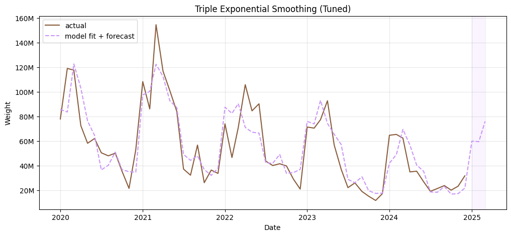

```python
triple_tuned = ExponentialSmoothing(
    data['Weight'],
    trend="additive",
    damped_trend=True,
    seasonal="multiplicative",
    seasonal_periods=12
).fit(optimized=True)

fitted = triple_tuned.fittedvalues

forecast_steps = 3
forecast = triple_tuned.forecast(steps=forecast_steps)

last_date = data['Import Date'].iloc[-1]
future_dates = pd.date_range(
    start=last_date + pd.offsets.MonthBegin(1),
    periods=forecast_steps,
    freq='MS'
)

combined_preds = np.concatenate([fitted.values, forecast.values])
combined_dates = pd.concat([data['Import Date'], pd.Series(future_dates)], ignore_index=True)

plt.figure(figsize=(12, 5))

plt.plot(data['Import Date'], data['Weight'], color=custom_palette[2], label="actual")

plt.plot(combined_dates, combined_preds, color=custom_palette[0], linestyle='--', label="model fit + forecast")

plt.axvspan(future_dates[0], future_dates[-1], color=custom_palette[0], alpha=0.1)

plt.gca().yaxis.set_major_formatter(FuncFormatter(lambda x, pos: f'{int(x/1e6)}M'))

plt.legend(loc='upper left')
plt.title("Triple Exponential Smoothing (Tuned)")
plt.xlabel("Date")
plt.ylabel("Weight")
plt.grid(alpha=0.3)
plt.show()
```

The Exponential Smoothing model does not provide Confidence Intervals, so I have manually bootstrapped them below (and later switch to ETS to replicate and report their built-in CI as another option):

Bootstrapped CI:

Note, I changed the CI to 80% to get a narrower forecast range which in this case with the CI being so wide would be practical. This is consistent with the default CI from Prophet. The 95% CIs were very wide and uninformative.

```python
def bootstrap_hw_intervals(model,train_values, horizon, n_boot=500):
    residuals = model.resid
    forecasts = np.zeros((n_boot, horizon))

    for i in range(n_boot):
        boot_sample = train_values + np.random.choice(residuals, size=len(train_values))
        boot_sample = np.maximum(boot_sample, 1e-6)

        boot_model = ExponentialSmoothing(
            boot_sample,
            trend="additive",
            damped_trend=True,
            seasonal="multiplicative",
            seasonal_periods=12
        ).fit(optimized=True)

        forecasts[i, :] = boot_model.forecast(steps=horizon)

    lower = np.percentile(forecasts, 10, axis=0)
    upper = np.percentile(forecasts, 90, axis=0)

    return pd.DataFrame({
        'horizon': range(1, horizon + 1),
        'point_forecast': model.forecast(steps=horizon),
        'ci_lower': lower,
        'ci_upper': upper
    })
```

Fit Holt-Winters Exponential Smoothing on full history:

```python
np.random.seed(42)

train_values = data['Weight'].values
final_hw = ExponentialSmoothing(
    train_values,
    trend="additive", damped_trend=True,
    seasonal="multiplicative", seasonal_periods=12
).fit(optimized=True)

ci_df = bootstrap_hw_intervals(final_hw, train_values, horizon=3, n_boot=500)
```

```python
ci_df.style.format("{:,.0f}")
```

|  | horizon | point_forecast | ci_lower | ci_upper |
| --- | --- | --- | --- | --- |
| 0 | 1 | 59,915,877 | 31,652,931 | 67,112,959 |
| 1 | 2 | 59,477,191 | 30,411,924 | 65,507,608 |
| 2 | 3 | 75,993,847 | 38,341,421 | 84,995,670 |

```python
future_dates = pd.date_range(
    start=data['Import Date'].iloc[-1] + pd.offsets.MonthBegin(1),
    periods=3,
    freq='MS'
)

forecast_table = pd.DataFrame({
    'Date': future_dates,
    'Forecast': ci_df['point_forecast'].round().astype(int),
    'Lower_80%_CI': np.floor(ci_df['ci_lower']).astype(int),
    'Upper_80%_CI': np.ceil(ci_df['ci_upper']).astype(int)
})
print(forecast_table)
```

```
        Date  Forecast  Lower_80%_CI  Upper_80%_CI
0 2025-01-01  59915877      31652931      67112960
1 2025-02-01  59477191      30411924      65507609
2 2025-03-01  75993847      38341421      84995671
```

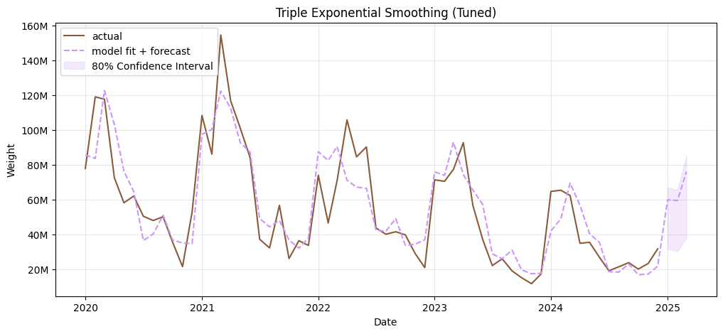

```python
triple_tuned = ExponentialSmoothing(
    data['Weight'],
    trend="additive",
    damped_trend=True,
    seasonal="multiplicative",
    seasonal_periods=12
).fit(optimized=True)

fitted = triple_tuned.fittedvalues
forecast_steps = 3
forecast = triple_tuned.forecast(steps=forecast_steps)

last_date = data['Import Date'].iloc[-1]
future_dates = pd.date_range(
    start=last_date + pd.offsets.MonthBegin(1),
    periods=forecast_steps,
    freq='MS'
)

combined_preds = np.concatenate([fitted.values, forecast.values])
combined_dates = pd.concat([data['Import Date'], pd.Series(future_dates)], ignore_index=True)

plt.figure(figsize=(12, 5))
plt.plot(data['Import Date'], data['Weight'], color=custom_palette[2], label="actual")
plt.plot(combined_dates, combined_preds, color=custom_palette[0], linestyle='--',
         label="model fit + forecast")

plt.fill_between(
    future_dates,
    ci_df['ci_lower'].values,
    ci_df['ci_upper'].values,
    color=custom_palette[0],
    alpha=0.2,
    label='80% Confidence Interval'
)

plt.gca().yaxis.set_major_formatter(FuncFormatter(lambda x, pos: f'{int(x/1e6)}M'))
plt.legend(loc='upper left')
plt.title("Triple Exponential Smoothing (Tuned)")
plt.xlabel("Date")
plt.ylabel("Weight")
plt.grid(alpha=0.3)
plt.show()
```

Log transformation:

Since the data is volatile, I also try out log transforming the data:

This showed no improvement over the Tuned Triple Exponential Smoothing with original data:

```python
train = data['Weight'][:-5]
test = data['Weight'][-5:]

triple_tuned_log = ExponentialSmoothing(np.log1p(train),
                              trend="additive",damped_trend=True,
                              seasonal="multiplicative",
                              seasonal_periods=12).fit(optimized=True)
triple_tuned_log_preds = np.expm1(triple_tuned_log.forecast(len(test)))
```

```python
train = data[:-5]
test = data[-5:]
```

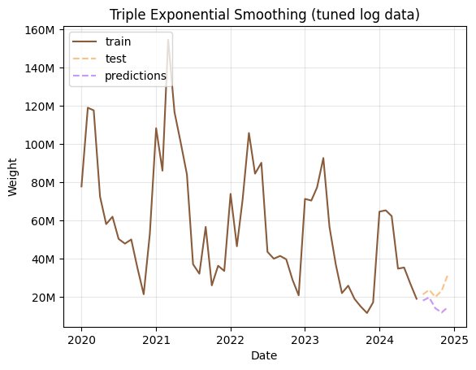

```python
plt.plot(train['Import Date'], train['Weight'], color=custom_palette[2], label="train")
plt.plot(test['Import Date'], test['Weight'], color=custom_palette[1], linestyle="--", label="test")
plt.plot(test['Import Date'], triple_tuned_log_preds, color=custom_palette[0], linestyle="--", label="predictions")

def millions(x, pos):
    return f'{int(x/1e6)}M'

plt.gca().yaxis.set_major_formatter(FuncFormatter(millions))

plt.legend(loc='upper left')
plt.title("Triple Exponential Smoothing (tuned log data)")
plt.xlabel("Date")
plt.ylabel("Weight")
plt.grid(alpha=0.3)
plt.show()
```

```python
horizon = 3
exp_ts_tuned_log_results = []

for cutoff in range(44, 60):
    if cutoff + horizon >= len(data):
        break

    train_log = np.log1p(data['Weight'].iloc[:cutoff + 1])

    triple_tuned_log = ExponentialSmoothing(
        train_log,
        trend="additive", damped_trend=True,
        seasonal="multiplicative", seasonal_periods=12
    ).fit(optimized=True)

    yhat_log = triple_tuned_log.forecast(steps=horizon)
    yhat = np.expm1(yhat_log)

    y_true = data['Weight'].iloc[cutoff + 1 : cutoff + 1 + horizon]

    for h in range(horizon):
        ae = abs(yhat.iloc[h] - y_true.iloc[h])
        ape = ae / max(abs(y_true.iloc[h]), 1e-8)

        exp_ts_tuned_log_results.append({
            'cutoff': cutoff,
            'horizon': h + 1,
            'cutoff_month': data['Import Date'].iloc[cutoff].to_period('M').to_timestamp(),
            'month': data['Import Date'].iloc[cutoff + h + 1].to_period('M').to_timestamp(),
            'y': y_true.iloc[h],
            'yhat': yhat.iloc[h],
            'AE': ae,
            'APE': ape
        })

exp_ts_tuned_log_cv_df = pd.DataFrame(exp_ts_tuned_log_results)
exp_ts_tuned_log_cv_df.style.format({
    'cutoff_month': '{:%m-%d-%Y}',
    'month': '{:%m-%d-%Y}',
    'y': '{:,.0f}',
    'yhat': '{:,.0f}',
    'AE': '{:,.0f}',
    'APE': '{:.0%}'
})
```

|  | cutoff | horizon | cutoff_month | month | y | yhat | AE | APE |
| --- | --- | --- | --- | --- | --- | --- | --- | --- |
| 0 | 44 | 1 | 09-01-2023 | 10-01-2023 | 15,172,388 | 18,717,066 | 3,544,678 | 23% |
| 1 | 44 | 2 | 09-01-2023 | 11-01-2023 | 11,741,002 | 16,070,641 | 4,329,639 | 37% |
| 2 | 44 | 3 | 09-01-2023 | 12-01-2023 | 17,305,596 | 18,858,823 | 1,553,227 | 9% |
| 3 | 45 | 1 | 10-01-2023 | 11-01-2023 | 11,741,002 | 14,724,691 | 2,983,689 | 25% |
| 4 | 45 | 2 | 10-01-2023 | 12-01-2023 | 17,305,596 | 17,270,935 | 34,661 | 0% |
| 5 | 45 | 3 | 10-01-2023 | 01-01-2024 | 64,702,033 | 39,771,856 | 24,930,177 | 39% |
| 6 | 46 | 1 | 11-01-2023 | 12-01-2023 | 17,305,596 | 15,722,629 | 1,582,967 | 9% |
| 7 | 46 | 2 | 11-01-2023 | 01-01-2024 | 64,702,033 | 36,045,965 | 28,656,068 | 44% |
| 8 | 46 | 3 | 11-01-2023 | 02-01-2024 | 65,375,575 | 33,847,619 | 31,527,956 | 48% |
| 9 | 47 | 1 | 12-01-2023 | 01-01-2024 | 64,702,033 | 37,501,335 | 27,200,698 | 42% |
| 10 | 47 | 2 | 12-01-2023 | 02-01-2024 | 65,375,575 | 35,207,647 | 30,167,928 | 46% |
| 11 | 47 | 3 | 12-01-2023 | 03-01-2024 | 62,364,919 | 45,811,770 | 16,553,149 | 27% |
| 12 | 48 | 1 | 01-01-2024 | 02-01-2024 | 65,375,575 | 42,546,741 | 22,828,834 | 35% |
| 13 | 48 | 2 | 01-01-2024 | 03-01-2024 | 62,364,919 | 55,507,300 | 6,857,619 | 11% |
| 14 | 48 | 3 | 01-01-2024 | 04-01-2024 | 34,933,233 | 53,048,403 | 18,115,170 | 52% |
| 15 | 49 | 1 | 02-01-2024 | 03-01-2024 | 62,364,919 | 65,023,435 | 2,658,516 | 4% |
| 16 | 49 | 2 | 02-01-2024 | 04-01-2024 | 34,933,233 | 62,077,162 | 27,143,929 | 78% |
| 17 | 49 | 3 | 02-01-2024 | 05-01-2024 | 35,504,037 | 47,850,759 | 12,346,722 | 35% |
| 18 | 50 | 1 | 03-01-2024 | 04-01-2024 | 34,933,233 | 61,005,118 | 26,071,885 | 75% |
| 19 | 50 | 2 | 03-01-2024 | 05-01-2024 | 35,504,037 | 47,037,305 | 11,533,268 | 32% |
| 20 | 50 | 3 | 03-01-2024 | 06-01-2024 | 26,935,635 | 41,935,796 | 15,000,161 | 56% |
| 21 | 51 | 1 | 04-01-2024 | 05-01-2024 | 35,504,037 | 39,710,590 | 4,206,553 | 12% |
| 22 | 51 | 2 | 04-01-2024 | 06-01-2024 | 26,935,635 | 35,457,392 | 8,521,757 | 32% |
| 23 | 51 | 3 | 04-01-2024 | 07-01-2024 | 19,175,494 | 20,560,354 | 1,384,860 | 7% |
| 24 | 52 | 1 | 05-01-2024 | 06-01-2024 | 26,935,635 | 34,303,281 | 7,367,646 | 27% |
| 25 | 52 | 2 | 05-01-2024 | 07-01-2024 | 19,175,494 | 19,913,667 | 738,173 | 4% |
| 26 | 52 | 3 | 05-01-2024 | 08-01-2024 | 21,449,146 | 19,408,741 | 2,040,405 | 10% |
| 27 | 53 | 1 | 06-01-2024 | 07-01-2024 | 19,175,494 | 18,493,004 | 682,490 | 4% |
| 28 | 53 | 2 | 06-01-2024 | 08-01-2024 | 21,449,146 | 18,030,222 | 3,418,924 | 16% |
| 29 | 53 | 3 | 06-01-2024 | 09-01-2024 | 23,828,291 | 19,633,621 | 4,194,670 | 18% |
| 30 | 54 | 1 | 07-01-2024 | 08-01-2024 | 21,449,146 | 18,245,027 | 3,204,119 | 15% |
| 31 | 54 | 2 | 07-01-2024 | 09-01-2024 | 23,828,291 | 19,868,026 | 3,960,265 | 17% |
| 32 | 54 | 3 | 07-01-2024 | 10-01-2024 | 20,121,692 | 14,249,175 | 5,872,517 | 29% |
| 33 | 55 | 1 | 08-01-2024 | 09-01-2024 | 23,828,291 | 20,858,982 | 2,969,309 | 12% |
| 34 | 55 | 2 | 08-01-2024 | 10-01-2024 | 20,121,692 | 14,943,318 | 5,178,374 | 26% |
| 35 | 55 | 3 | 08-01-2024 | 11-01-2024 | 23,311,088 | 12,556,075 | 10,755,013 | 46% |
| 36 | 56 | 1 | 09-01-2024 | 10-01-2024 | 20,121,692 | 15,513,082 | 4,608,610 | 23% |
| 37 | 56 | 2 | 09-01-2024 | 11-01-2024 | 23,311,088 | 13,028,289 | 10,282,799 | 44% |
| 38 | 56 | 3 | 09-01-2024 | 12-01-2024 | 31,759,202 | 16,112,426 | 15,646,776 | 49% |

```python
exp_ts_tuned_log_cv = exp_ts_tuned_log_cv_df.groupby('horizon').agg(
    MAE=('AE', 'mean'),
    MAPE=('APE', 'mean'))

exp_ts_tuned_log_cv.style.format({
    'MAE': '{:,.0f}',
    'MAPE': '{:.0%}'})
```

| horizon | MAE | MAPE |
| --- | --- | --- |
| 1 | 8,454,615 | 24% |
| 2 | 10,832,569 | 30% |
| 3 | 12,301,600 | 33% |

The performance is slightly worse than without the log transformation:

```python
exp_ts_tuned_log_overall_MAE  = exp_ts_tuned_log_cv_df['AE'].mean()
exp_ts_tuned_log_overall_MAPE = exp_ts_tuned_log_cv_df['APE'].mean()

print(f"MAE: {exp_ts_tuned_log_overall_MAE:,.0f}")
print(f"MAPE (%): {exp_ts_tuned_log_overall_MAPE:.0%}")
```

```
MAE: 10,529,595
MAPE (%): 29%
```

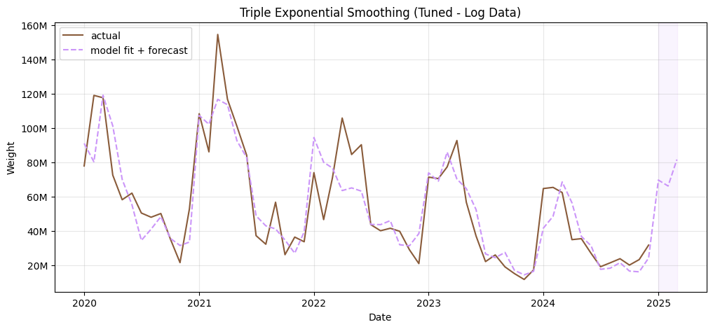

```python
triple_tuned_log = ExponentialSmoothing(
    np.log1p(data['Weight']),
    trend="additive",
    damped_trend=True,
    seasonal="multiplicative",
    seasonal_periods=12
).fit(optimized=True)

fitted_log = np.expm1(triple_tuned_log.fittedvalues)

forecast_steps = 3
forecast_log = np.expm1(triple_tuned_log.forecast(steps=forecast_steps))

last_date = data['Import Date'].iloc[-1]
future_dates = pd.date_range(
    start=last_date + pd.offsets.MonthBegin(1),
    periods=forecast_steps,
    freq='MS'
)

combined_preds_log = np.concatenate([fitted_log.values, forecast_log.values])
combined_dates_log = pd.concat([data['Import Date'], pd.Series(future_dates)], ignore_index=True)

plt.figure(figsize=(12, 5))

plt.plot(data['Import Date'], data['Weight'], color=custom_palette[2], label="actual")

plt.plot(combined_dates_log, combined_preds_log, color=custom_palette[0], linestyle='--', label="model fit + forecast")

plt.axvspan(future_dates[0], future_dates[-1], color=custom_palette[0], alpha=0.1)

plt.gca().yaxis.set_major_formatter(FuncFormatter(lambda x, pos: f'{int(x/1e6)}M'))

plt.legend(loc='upper left')
plt.title("Triple Exponential Smoothing (Tuned - Log Data)")
plt.xlabel("Date")
plt.ylabel("Weight")
plt.grid(alpha=0.3)
plt.show()
```

Add CI:

```python
def bootstrap_hw_intervals(model,train_values, horizon, n_boot=500):
    residuals = model.resid
    forecasts = np.zeros((n_boot, horizon))

    for i in range(n_boot):
        boot_sample = train_values + np.random.choice(residuals, size=len(train_values))
        boot_sample = np.maximum(boot_sample, 1e-6)

        boot_model = ExponentialSmoothing(
            boot_sample,
            trend="additive",
            damped_trend=True,
            seasonal="multiplicative",
            seasonal_periods=12
        ).fit(optimized=True)

        forecasts[i, :] = np.expm1(boot_model.forecast(steps=horizon))

    lower = np.percentile(forecasts, 10, axis=0)
    upper = np.percentile(forecasts, 90, axis=0)

    return pd.DataFrame({
        'horizon': range(1, horizon + 1),
        'point_forecast': np.expm1(model.forecast(steps=horizon)),
        'ci_lower': lower,
        'ci_upper': upper
    })
```

```python
np.random.seed(42)

train_values = np.log1p(data['Weight'].values)
final_hw = ExponentialSmoothing(
    train_values,
    trend="additive", damped_trend=True,
    seasonal="multiplicative", seasonal_periods=12
).fit(optimized=True)

ci_df = bootstrap_hw_intervals(final_hw, train_values, horizon=3, n_boot=500)
```

```python
ci_df.style.format("{:.0f}")
```

|  | horizon | point_forecast | ci_lower | ci_upper |
| --- | --- | --- | --- | --- |
| 0 | 1 | 69648880 | 42252001 | 73726954 |
| 1 | 2 | 66175597 | 40121527 | 69833012 |
| 2 | 3 | 81596208 | 50389155 | 86459868 |

```python
future_dates = pd.date_range(
    start=data['Import Date'].iloc[-1] + pd.offsets.MonthBegin(1),
    periods=3,
    freq='MS'
)

forecast_table = pd.DataFrame({
    'Date': future_dates,
    'Forecast': ci_df['point_forecast'].round().astype(int),
    'Lower_80_CI': np.floor(ci_df['ci_lower']).astype(int),
    'Upper_80_CI': np.ceil(ci_df['ci_upper']).astype(int)
})
print(forecast_table)
```

```
        Date  Forecast  Lower_80_CI  Upper_80_CI
0 2025-01-01  69648880     42252001     73726955
1 2025-02-01  66175597     40121527     69833012
2 2025-03-01  81596208     50389155     86459868
```

[figure not shown]

```python
triple_tuned_log = ExponentialSmoothing(
    np.log1p(data['Weight']),
    trend="additive",
    damped_trend=True,
    seasonal="multiplicative",
    seasonal_periods=12
).fit(optimized=True)

fitted = np.expm1(triple_tuned_log.fittedvalues)
forecast_steps = 3
forecast = np.expm1(triple_tuned_log.forecast(steps=forecast_steps))

last_date = data['Import Date'].iloc[-1]
future_dates = pd.date_range(
    start=last_date + pd.offsets.MonthBegin(1),
    periods=forecast_steps,
    freq='MS'
)

combined_preds_log = np.concatenate([fitted.values, forecast.values])
combined_dates_log = pd.concat([data['Import Date'], pd.Series(future_dates)], ignore_index=True)

plt.figure(figsize=(12, 5))
plt.plot(data['Import Date'], data['Weight'], color=custom_palette[2], label="actual")
plt.plot(combined_dates, combined_preds, color=custom_palette[0], linestyle='--',
         label="model fit + forecast")

plt.fill_between(
    future_dates,
    ci_df['ci_lower'].values,
    ci_df['ci_upper'].values,
    color=custom_palette[0],
    alpha=0.2,
    label='80% Confidence Interval'
)

plt.gca().yaxis.set_major_formatter(FuncFormatter(lambda x, pos: f'{int(x/1e6)}M'))
plt.legend(loc='upper left')
plt.title("Triple Exponential Smoothing (Tuned - Log Data)")
plt.xlabel("Date")
plt.ylabel("Weight")
plt.grid(alpha=0.3)
plt.show()
```

## Model 2: SARIMA

I next chose the SARIMA model to see if performance improved. It seemed like a good option given that the data is nonstationary and there is seasonality:

From earlier plots: (For non-log data) ACF has 1,2,12 lags and PACF has 1,12 lags

| Model | Plot | Observation |
| --- | --- | --- |
| **AR(p)** | **PACF** | Cuts off after lag **p** |
| **MA(q)** | **ACF** | Cuts off after lag **q** |

PACF lag 1 → p = 1

ACF lag 1–2 → q = 2

Non-seasonal parameters: (p, q) = (1, 2). d in (p,d,q) will be determined from differencing below.

PACF at lag 12 → seasonal AR → P = 1

ACF at lag 12 → seasonal MA → Q = 1

There were no spikes at 24, 36 so will not consider higher orders.

Seasonal differencing D: D =1 if strong spike on ACF at lag 12.

The results (including differencing below) point to (1,1,2) (1,1,1,12) being the ideal orders for the non-log data.

```python
data.head()
```

|  | Import Date | Weight |
| --- | --- | --- |
| 0 | 2020-01-01 | 77863938 |
| 1 | 2020-02-01 | 118967413 |
| 2 | 2020-03-01 | 117594405 |
| 3 | 2020-04-01 | 72523979 |
| 4 | 2020-05-01 | 58180114 |

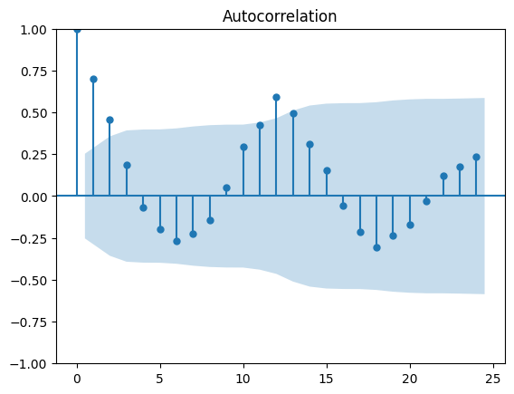

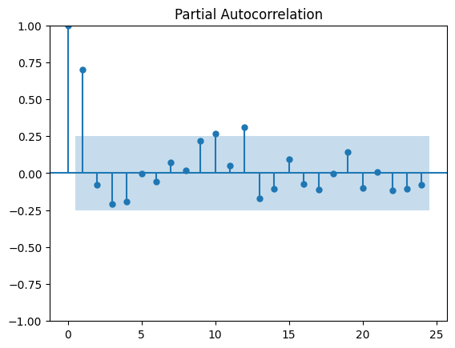

```python
plot_acf(data['Weight'], lags=24)
plot_pacf(data['Weight'], lags=24)
plt.show()
```

```python
data['y_diff'] = data['Weight'].diff()
```

```python
diff_for_df_test = pd.DataFrame(data, columns=['Import Date','y_diff'])
```

```python
diff_for_df_test.head()
```

|  | Import Date | y_diff |
| --- | --- | --- |
| 0 | 2020-01-01 | NaN |
| 1 | 2020-02-01 | 41103475.0 |
| 2 | 2020-03-01 | -1373008.0 |
| 3 | 2020-04-01 | -45070426.0 |
| 4 | 2020-05-01 | -14343865.0 |

Passes Dickey Fuller Test after differencing 1 time (stationary now). Do not need to difference again. Will set d=1.

```python
adf_b4, pvalue_b4, usedlag_, nobs_, critical_values_, icbest_ = adfuller(diff_for_df_test['y_diff'].dropna())

print(f"ADF: {adf_b4:.2f}")
print(f"p-value: {pvalue_b4:.8f}")
```

```
ADF: -5.83
p-value: 0.00000040
```

The ideal parameters appear to be (2,1,1) (1,1,1,12) for log data:

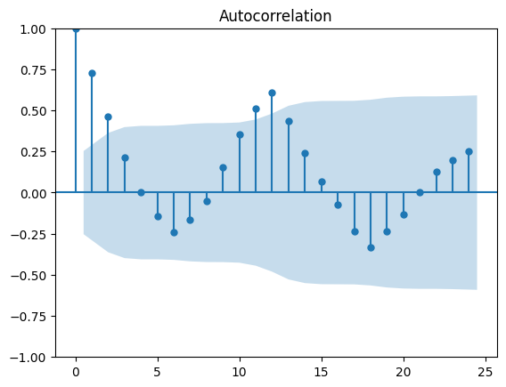

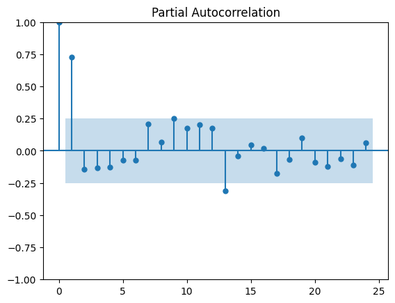

```python
plot_acf(np.log1p(data['Weight']), lags=24)
plot_pacf(np.log1p(data['Weight']), lags=24)
plt.show()
```

Differencing with Log (to validate d=1):

```python
data_log = data.copy()
```

```python
data_log['y_diff'] = np.log1p(data_log['Weight']).diff()
```

```python
diff_for_df_test_log = pd.DataFrame(data_log, columns=['Import Date','y_diff'])
```

```python
diff_for_df_test_log.head()
```

|  | Import Date | y_diff |
| --- | --- | --- |
| 0 | 2020-01-01 | NaN |
| 1 | 2020-02-01 | 0.423887 |
| 2 | 2020-03-01 | -0.011608 |
| 3 | 2020-04-01 | -0.483324 |
| 4 | 2020-05-01 | -0.220374 |

```python
adf_b4, pvalue_b4, usedlag_, nobs_, critical_values_, icbest_ = adfuller(diff_for_df_test_log['y_diff'].dropna())

print(f"ADF: {adf_b4:.2f}")
print(f"p-value: {pvalue_b4:.4f}")
```

```
ADF: -3.08
p-value: 0.0282
```

d=1 since differencing was solved with 1 difference

Manual model with parameters from above:

```python
sar_manual = sm.tsa.statespace.SARIMAX(data['Weight'],
                                order=(1,1,2),
                                seasonal_order=(1,1,1,12),
                                trend='c').fit()
```

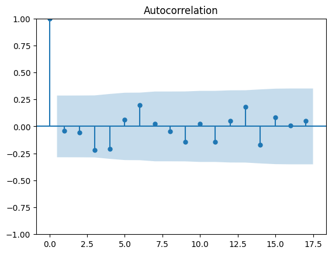

```python
sm.tsa.graphics.plot_acf(sar_manual.resid[sar_manual.loglikelihood_burn:]);
```

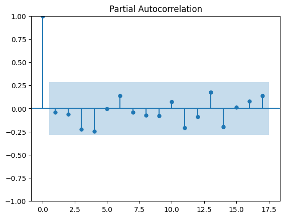

```python
sm.tsa.graphics.plot_pacf(sar_manual.resid[sar_manual.loglikelihood_burn:]);
```

Diagnostics are pretty good: residuals look like white noise, only slight right skew on histogram of residuals, q-q plot has some deviation at the upper right, but no autocorrelation (!):

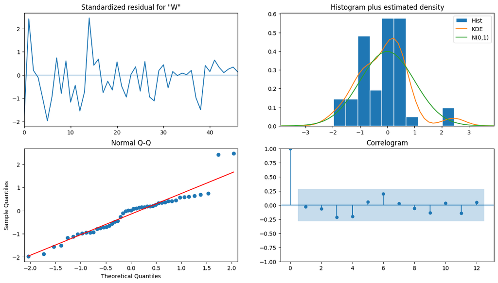

```python
sar_manual.plot_diagnostics(figsize = (15,8),lags = 12);
```

Inputting ideal manual option (based on visuals/tests):

```python
horizon = 3
manual_results = []

for cutoff in range(44, 60):
    if cutoff + horizon >= len(data):
        break

    train = data.iloc[:cutoff+1]

    sar_manual = sm.tsa.SARIMAX(
        train['Weight'],
        order=(1,1,2),
        seasonal_order=(1,1,1,12),
        trend='c',
        use_exact_diffuse=True
    ).fit(disp=False)

    yhat = sar_manual.forecast(steps=horizon)
    y_true = data['Weight'].iloc[cutoff+1: cutoff+1 + horizon]

    for h in range(horizon):
        ae = abs(yhat.iloc[h] - y_true.iloc[h])
        ape = ae / max(abs(y_true.iloc[h]), 1e-8)

        manual_results.append({
            'cutoff': cutoff,
            'horizon': h + 1,
            'cutoff_month': data['Import Date'].iloc[cutoff].to_period('M').to_timestamp(),
            'month': data['Import Date'].iloc[cutoff + h + 1].to_period('M').to_timestamp(),
            'y': y_true.iloc[h],
            'yhat': yhat.iloc[h],
            'AE': ae,
            'APE': ape
        })

sarima_manual_cv_df = pd.DataFrame(manual_results)
sarima_manual_cv_df.style.format({
    'cutoff_month': '{:%m-%d-%Y}',
    'month': '{:%m-%d-%Y}',
    'y': '{:,.0f}',
    'yhat': '{:,.0f}',
    'AE': '{:,.0f}',
    'APE': '{:.0%}'
})
```

|  | cutoff | horizon | cutoff_month | month | y | yhat | AE | APE |
| --- | --- | --- | --- | --- | --- | --- | --- | --- |
| 0 | 44 | 1 | 09-01-2023 | 10-01-2023 | 15,172,388 | -902,180 | 16,074,568 | 106% |
| 1 | 44 | 2 | 09-01-2023 | 11-01-2023 | 11,741,002 | -7,499,335 | 19,240,337 | 164% |
| 2 | 44 | 3 | 09-01-2023 | 12-01-2023 | 17,305,596 | -8,421,289 | 25,726,885 | 149% |
| 3 | 45 | 1 | 10-01-2023 | 11-01-2023 | 11,741,002 | -1,016,610 | 12,757,612 | 109% |
| 4 | 45 | 2 | 10-01-2023 | 12-01-2023 | 17,305,596 | -6,792,540 | 24,098,136 | 139% |
| 5 | 45 | 3 | 10-01-2023 | 01-01-2024 | 64,702,033 | 41,323,640 | 23,378,393 | 36% |
| 6 | 46 | 1 | 11-01-2023 | 12-01-2023 | 17,305,596 | -3,223,811 | 20,529,407 | 119% |
| 7 | 46 | 2 | 11-01-2023 | 01-01-2024 | 64,702,033 | 40,478,792 | 24,223,241 | 37% |
| 8 | 46 | 3 | 11-01-2023 | 02-01-2024 | 65,375,575 | 30,235,118 | 35,140,457 | 54% |
| 9 | 47 | 1 | 12-01-2023 | 01-01-2024 | 64,702,033 | 55,283,347 | 9,418,686 | 15% |
| 10 | 47 | 2 | 12-01-2023 | 02-01-2024 | 65,375,575 | 47,623,246 | 17,752,329 | 27% |
| 11 | 47 | 3 | 12-01-2023 | 03-01-2024 | 62,364,919 | 63,009,160 | 644,241 | 1% |
| 12 | 48 | 1 | 01-01-2024 | 02-01-2024 | 65,375,575 | 52,854,378 | 12,521,197 | 19% |
| 13 | 48 | 2 | 01-01-2024 | 03-01-2024 | 62,364,919 | 66,474,374 | 4,109,455 | 7% |
| 14 | 48 | 3 | 01-01-2024 | 04-01-2024 | 34,933,233 | 65,836,481 | 30,903,248 | 88% |
| 15 | 49 | 1 | 02-01-2024 | 03-01-2024 | 62,364,919 | 72,268,490 | 9,903,571 | 16% |
| 16 | 49 | 2 | 02-01-2024 | 04-01-2024 | 34,933,233 | 67,093,854 | 32,160,621 | 92% |
| 17 | 49 | 3 | 02-01-2024 | 05-01-2024 | 35,504,037 | 38,321,713 | 2,817,676 | 8% |
| 18 | 50 | 1 | 03-01-2024 | 04-01-2024 | 34,933,233 | 60,309,139 | 25,375,906 | 73% |
| 19 | 50 | 2 | 03-01-2024 | 05-01-2024 | 35,504,037 | 34,852,914 | 651,123 | 2% |
| 20 | 50 | 3 | 03-01-2024 | 06-01-2024 | 26,935,635 | 23,152,994 | 3,782,641 | 14% |
| 21 | 51 | 1 | 04-01-2024 | 05-01-2024 | 35,504,037 | 21,708,625 | 13,795,412 | 39% |
| 22 | 51 | 2 | 04-01-2024 | 06-01-2024 | 26,935,635 | 13,630,593 | 13,305,042 | 49% |
| 23 | 51 | 3 | 04-01-2024 | 07-01-2024 | 19,175,494 | -18,494,471 | 37,669,965 | 196% |
| 24 | 52 | 1 | 05-01-2024 | 06-01-2024 | 26,935,635 | 23,568,084 | 3,367,551 | 13% |
| 25 | 52 | 2 | 05-01-2024 | 07-01-2024 | 19,175,494 | -12,111,752 | 31,287,246 | 163% |
| 26 | 52 | 3 | 05-01-2024 | 08-01-2024 | 21,449,146 | -14,159,671 | 35,608,817 | 166% |
| 27 | 53 | 1 | 06-01-2024 | 07-01-2024 | 19,175,494 | -8,456,164 | 27,631,658 | 144% |
| 28 | 53 | 2 | 06-01-2024 | 08-01-2024 | 21,449,146 | -10,905,403 | 32,354,549 | 151% |
| 29 | 53 | 3 | 06-01-2024 | 09-01-2024 | 23,828,291 | -10,683,873 | 34,512,164 | 145% |
| 30 | 54 | 1 | 07-01-2024 | 08-01-2024 | 21,449,146 | 3,732,004 | 17,717,142 | 83% |
| 31 | 54 | 2 | 07-01-2024 | 09-01-2024 | 23,828,291 | -3,279,741 | 27,108,032 | 114% |
| 32 | 54 | 3 | 07-01-2024 | 10-01-2024 | 20,121,692 | -15,329,868 | 35,451,560 | 176% |
| 33 | 55 | 1 | 08-01-2024 | 09-01-2024 | 23,828,291 | 2,210,775 | 21,617,516 | 91% |
| 34 | 55 | 2 | 08-01-2024 | 10-01-2024 | 20,121,692 | -15,338,954 | 35,460,646 | 176% |
| 35 | 55 | 3 | 08-01-2024 | 11-01-2024 | 23,311,088 | -20,710,154 | 44,021,242 | 189% |
| 36 | 56 | 1 | 09-01-2024 | 10-01-2024 | 20,121,692 | -3,428,949 | 23,550,641 | 117% |
| 37 | 56 | 2 | 09-01-2024 | 11-01-2024 | 23,311,088 | -15,752,620 | 39,063,708 | 168% |
| 38 | 56 | 3 | 09-01-2024 | 12-01-2024 | 31,759,202 | -12,801,763 | 44,560,965 | 140% |

```python
sarima_manual_cv = sarima_manual_cv_df.groupby('horizon').agg(
    MAE=('AE', 'mean'),
    MAPE=('APE', 'mean'))

sarima_manual_cv.style.format({
    'MAE': '{:,.0f}',
    'MAPE': '{:.0%}'})
```

| horizon | MAE | MAPE |
| --- | --- | --- |
| 1 | 16,481,605 | 72% |
| 2 | 23,139,574 | 99% |
| 3 | 27,247,558 | 105% |

The MAPE is extremely high which is surprising, given that this was the intuitively ideal combo of parameters. However, this is on the non-log transformed data.

```python
sarima_manual_overall_MAE  = sarima_manual_cv_df['AE'].mean()
sarima_manual_overall_MAPE = sarima_manual_cv_df['APE'].mean()

print(f"MAE: {sarima_manual_overall_MAE:,.0f}")
print(f"MAPE (%): {sarima_manual_overall_MAPE:.0%}")
```

```
MAE: 22,289,579
MAPE (%): 92%
```

Run Auto-ARIMA to either verify selected parameters or identify more optimal ones:

This "auto" option iterates through options, but with safeguards to min/max parameters based on previous decomposition/visuals/tests:

Forcing d and D to be 1 and letting the rest run:

```python
sarima_auto_model = pm.auto_arima(data['Weight'],
                          start_p=0,
                          d=1,
                          start_q=0,
                          max_p=5,
                          max_d=1,
                          max_q=5,
                          start_P=0,
                          D=1,
                          start_Q=0,
                          max_P=2,
                          max_D=1,
                          max_Q=2,
                          max_order=5,
                          m=12,
                          seasonal=True,
                          stepwise=False,
                          suppress_warnings=True,
                          error_action='trace',
                          trace=True,
                          random_state=42
                          )
```

```
 ARIMA(0,1,0)(0,1,0)[12]             : AIC=1739.523, Time=0.00 sec
 ARIMA(0,1,0)(0,1,1)[12]             : AIC=inf, Time=0.03 sec
 ARIMA(0,1,0)(0,1,2)[12]             : AIC=1727.007, Time=0.06 sec
 ARIMA(0,1,0)(1,1,0)[12]             : AIC=1738.266, Time=0.01 sec
 ARIMA(0,1,0)(1,1,1)[12]             : AIC=inf, Time=0.05 sec
 ARIMA(0,1,0)(1,1,2)[12]             : AIC=1727.890, Time=0.08 sec
 ARIMA(0,1,0)(2,1,0)[12]             : AIC=1736.318, Time=0.05 sec
 ARIMA(0,1,0)(2,1,1)[12]             : AIC=1736.740, Time=0.07 sec
 ARIMA(0,1,0)(2,1,2)[12]             : AIC=1727.517, Time=0.12 sec
 ARIMA(0,1,1)(0,1,0)[12]             : AIC=1735.337, Time=0.01 sec
 ARIMA(0,1,1)(0,1,1)[12]             : AIC=1721.028, Time=0.03 sec
 ARIMA(0,1,1)(0,1,2)[12]             : AIC=1720.941, Time=0.08 sec
 ARIMA(0,1,1)(1,1,0)[12]             : AIC=1733.606, Time=0.02 sec
 ARIMA(0,1,1)(1,1,1)[12]             : AIC=1722.198, Time=0.05 sec
 ARIMA(0,1,1)(1,1,2)[12]             : AIC=1721.538, Time=0.10 sec
 ARIMA(0,1,1)(2,1,0)[12]             : AIC=1721.445, Time=0.05 sec
 ARIMA(0,1,1)(2,1,1)[12]             : AIC=1719.400, Time=0.08 sec
 ARIMA(0,1,1)(2,1,2)[12]             : AIC=1721.047, Time=0.18 sec
 ARIMA(0,1,2)(0,1,0)[12]             : AIC=1735.734, Time=0.01 sec
 ARIMA(0,1,2)(0,1,1)[12]             : AIC=1721.761, Time=0.04 sec
 ARIMA(0,1,2)(0,1,2)[12]             : AIC=1721.263, Time=0.05 sec
 ARIMA(0,1,2)(1,1,0)[12]             : AIC=1734.642, Time=0.03 sec
 ARIMA(0,1,2)(1,1,1)[12]             : AIC=1722.765, Time=0.06 sec
 ARIMA(0,1,2)(1,1,2)[12]             : AIC=1721.810, Time=0.08 sec
 ARIMA(0,1,2)(2,1,0)[12]             : AIC=1722.370, Time=0.07 sec
 ARIMA(0,1,2)(2,1,1)[12]             : AIC=1719.626, Time=0.11 sec
 ARIMA(0,1,3)(0,1,0)[12]             : AIC=1738.216, Time=0.01 sec
 ARIMA(0,1,3)(0,1,1)[12]             : AIC=1723.205, Time=0.05 sec
 ARIMA(0,1,3)(0,1,2)[12]             : AIC=inf, Time=0.13 sec
 ARIMA(0,1,3)(1,1,0)[12]             : AIC=1736.785, Time=0.03 sec
 ARIMA(0,1,3)(1,1,1)[12]             : AIC=inf, Time=0.10 sec
 ARIMA(0,1,3)(2,1,0)[12]             : AIC=1724.118, Time=0.08 sec
 ARIMA(0,1,4)(0,1,0)[12]             : AIC=1752.785, Time=0.02 sec
 ARIMA(0,1,4)(0,1,1)[12]             : AIC=inf, Time=0.20 sec
 ARIMA(0,1,4)(1,1,0)[12]             : AIC=1749.054, Time=0.05 sec
 ARIMA(0,1,5)(0,1,0)[12]             : AIC=1749.277, Time=0.03 sec
 ARIMA(1,1,0)(0,1,0)[12]             : AIC=1737.477, Time=0.01 sec
 ARIMA(1,1,0)(0,1,1)[12]             : AIC=1722.759, Time=0.02 sec
 ARIMA(1,1,0)(0,1,2)[12]             : AIC=1723.188, Time=0.08 sec
 ARIMA(1,1,0)(1,1,0)[12]             : AIC=1735.043, Time=0.02 sec
```

[output cut: 44 more lines]

```
 ARIMA(3,1,0)(1,1,0)[12]             : AIC=1738.185, Time=0.03 sec
 ARIMA(3,1,0)(1,1,1)[12]             : AIC=1725.766, Time=0.08 sec
 ARIMA(3,1,0)(2,1,0)[12]             : AIC=1724.963, Time=0.05 sec
 ARIMA(3,1,1)(0,1,0)[12]             : AIC=1738.339, Time=0.02 sec
 ARIMA(3,1,1)(0,1,1)[12]             : AIC=1726.101, Time=0.07 sec
 ARIMA(3,1,1)(1,1,0)[12]             : AIC=1737.398, Time=0.06 sec
 ARIMA(3,1,2)(0,1,0)[12]             : AIC=inf, Time=0.09 sec
 ARIMA(4,1,0)(0,1,0)[12]             : AIC=1738.851, Time=0.02 sec
 ARIMA(4,1,0)(0,1,1)[12]             : AIC=1723.257, Time=0.06 sec
 ARIMA(4,1,0)(1,1,0)[12]             : AIC=1737.427, Time=0.05 sec
 ARIMA(4,1,1)(0,1,0)[12]             : AIC=1740.138, Time=0.03 sec
 ARIMA(5,1,0)(0,1,0)[12]             : AIC=1740.185, Time=0.02 sec

Best model:  ARIMA(0,1,1)(2,1,1)[12]
Total fit time: 6.406 seconds
```

Best model parameters:

```python
print('order: ',sarima_auto_model.order)
print('seasonal order: ',sarima_auto_model.seasonal_order)
```

```
order:  (0, 1, 1)
seasonal order:  (2, 1, 1, 12)
```

```python
horizon = 3
auto_results = []

for cutoff in range(44, 60):
    if cutoff + horizon >= len(data):
        break

    train = data.iloc[:cutoff+1]

    sar_auto = sm.tsa.SARIMAX(
        train['Weight'],
        order=sarima_auto_model.order,
        seasonal_order=sarima_auto_model.seasonal_order,
        trend='c',
        use_exact_diffuse=True
    ).fit(disp=False)

    yhat = sar_auto.forecast(steps=horizon)
    y_true = data['Weight'].iloc[cutoff+1: cutoff+1 + horizon]

    for h in range(horizon):
        ae = abs(yhat.iloc[h] - y_true.iloc[h])
        ape = ae / max(abs(y_true.iloc[h]), 1e-8)

        auto_results.append({
            'cutoff': cutoff,
            'horizon': h + 1,
            'cutoff_month': data['Import Date'].iloc[cutoff].to_period('M').to_timestamp(),
            'month': data['Import Date'].iloc[cutoff + h + 1].to_period('M').to_timestamp(),
            'y': y_true.iloc[h],
            'yhat': yhat.iloc[h],
            'AE': ae,
            'APE': ape
        })

sarima_auto_cv_df = pd.DataFrame(auto_results)
sarima_auto_cv_df.style.format({
    'cutoff_month': '{:%m-%d-%Y}',
    'month': '{:%m-%d-%Y}',
    'y': '{:,.0f}',
    'yhat': '{:,.0f}',
    'AE': '{:,.0f}',
    'APE': '{:.0%}'
})
```

|  | cutoff | horizon | cutoff_month | month | y | yhat | AE | APE |
| --- | --- | --- | --- | --- | --- | --- | --- | --- |
| 0 | 44 | 1 | 09-01-2023 | 10-01-2023 | 15,172,388 | 9,171,902 | 6,000,486 | 40% |
| 1 | 44 | 2 | 09-01-2023 | 11-01-2023 | 11,741,002 | -6,703,573 | 18,444,575 | 157% |
| 2 | 44 | 3 | 09-01-2023 | 12-01-2023 | 17,305,596 | 21,158 | 17,284,438 | 100% |
| 3 | 45 | 1 | 10-01-2023 | 11-01-2023 | 11,741,002 | -4,836,305 | 16,577,307 | 141% |
| 4 | 45 | 2 | 10-01-2023 | 12-01-2023 | 17,305,596 | 2,482,824 | 14,822,772 | 86% |
| 5 | 45 | 3 | 10-01-2023 | 01-01-2024 | 64,702,033 | 53,761,074 | 10,940,959 | 17% |
| 6 | 46 | 1 | 11-01-2023 | 12-01-2023 | 17,305,596 | 9,707,022 | 7,598,574 | 44% |
| 7 | 46 | 2 | 11-01-2023 | 01-01-2024 | 64,702,033 | 61,134,415 | 3,567,618 | 6% |
| 8 | 46 | 3 | 11-01-2023 | 02-01-2024 | 65,375,575 | 46,124,995 | 19,250,580 | 29% |
| 9 | 47 | 1 | 12-01-2023 | 01-01-2024 | 64,702,033 | 65,319,948 | 617,915 | 1% |
| 10 | 47 | 2 | 12-01-2023 | 02-01-2024 | 65,375,575 | 52,069,485 | 13,306,090 | 20% |
| 11 | 47 | 3 | 12-01-2023 | 03-01-2024 | 62,364,919 | 86,732,571 | 24,367,652 | 39% |
| 12 | 48 | 1 | 01-01-2024 | 02-01-2024 | 65,375,575 | 52,436,703 | 12,938,872 | 20% |
| 13 | 48 | 2 | 01-01-2024 | 03-01-2024 | 62,364,919 | 87,391,728 | 25,026,809 | 40% |
| 14 | 48 | 3 | 01-01-2024 | 04-01-2024 | 34,933,233 | 74,850,371 | 39,917,138 | 114% |
| 15 | 49 | 1 | 02-01-2024 | 03-01-2024 | 62,364,919 | 92,159,107 | 29,794,188 | 48% |
| 16 | 49 | 2 | 02-01-2024 | 04-01-2024 | 34,933,233 | 75,064,196 | 40,130,963 | 115% |
| 17 | 49 | 3 | 02-01-2024 | 05-01-2024 | 35,504,037 | 46,796,129 | 11,292,092 | 32% |
| 18 | 50 | 1 | 03-01-2024 | 04-01-2024 | 34,933,233 | 60,741,215 | 25,807,982 | 74% |
| 19 | 50 | 2 | 03-01-2024 | 05-01-2024 | 35,504,037 | 31,769,359 | 3,734,678 | 11% |
| 20 | 50 | 3 | 03-01-2024 | 06-01-2024 | 26,935,635 | 12,552,359 | 14,383,276 | 53% |
| 21 | 51 | 1 | 04-01-2024 | 05-01-2024 | 35,504,037 | 11,965,763 | 23,538,274 | 66% |
| 22 | 51 | 2 | 04-01-2024 | 06-01-2024 | 26,935,635 | -10,041,439 | 36,977,074 | 137% |
| 23 | 51 | 3 | 04-01-2024 | 07-01-2024 | 19,175,494 | -37,034,263 | 56,209,757 | 293% |
| 24 | 52 | 1 | 05-01-2024 | 06-01-2024 | 26,935,635 | 4,928,421 | 22,007,214 | 82% |
| 25 | 52 | 2 | 05-01-2024 | 07-01-2024 | 19,175,494 | -22,805,022 | 41,980,516 | 219% |
| 26 | 52 | 3 | 05-01-2024 | 08-01-2024 | 21,449,146 | -26,290,054 | 47,739,200 | 223% |
| 27 | 53 | 1 | 06-01-2024 | 07-01-2024 | 19,175,494 | -12,536,504 | 31,711,998 | 165% |
| 28 | 53 | 2 | 06-01-2024 | 08-01-2024 | 21,449,146 | -15,708,953 | 37,158,099 | 173% |
| 29 | 53 | 3 | 06-01-2024 | 09-01-2024 | 23,828,291 | -12,987,106 | 36,815,397 | 155% |
| 30 | 54 | 1 | 07-01-2024 | 08-01-2024 | 21,449,146 | -249,107 | 21,698,253 | 101% |
| 31 | 54 | 2 | 07-01-2024 | 09-01-2024 | 23,828,291 | 1,400,654 | 22,427,637 | 94% |
| 32 | 54 | 3 | 07-01-2024 | 10-01-2024 | 20,121,692 | -15,332,896 | 35,454,588 | 176% |
| 33 | 55 | 1 | 08-01-2024 | 09-01-2024 | 23,828,291 | 15,193,058 | 8,635,233 | 36% |
| 34 | 55 | 2 | 08-01-2024 | 10-01-2024 | 20,121,692 | -1,390,429 | 21,512,121 | 107% |
| 35 | 55 | 3 | 08-01-2024 | 11-01-2024 | 23,311,088 | -5,421,165 | 28,732,253 | 123% |
| 36 | 56 | 1 | 09-01-2024 | 10-01-2024 | 20,121,692 | 4,311,734 | 15,809,958 | 79% |
| 37 | 56 | 2 | 09-01-2024 | 11-01-2024 | 23,311,088 | 759,819 | 22,551,269 | 97% |
| 38 | 56 | 3 | 09-01-2024 | 12-01-2024 | 31,759,202 | 8,134,898 | 23,624,304 | 74% |

```python
sarima_auto_cv = sarima_auto_cv_df.groupby('horizon').agg(
    MAE=('AE', 'mean'),
    MAPE=('APE', 'mean'))

sarima_auto_cv.style.format({
    'MAE': '{:,.0f}',
    'MAPE': '{:.0%}'})
```

| horizon | MAE | MAPE |
| --- | --- | --- |
| 1 | 17,133,558 | 69% |
| 2 | 23,203,094 | 97% |
| 3 | 28,154,741 | 110% |

```python
sarima_auto_overall_MAE  = sarima_auto_cv_df['AE'].mean()
sarima_auto_overall_MAPE = sarima_auto_cv_df['APE'].mean()

print(f"MAE: {sarima_auto_overall_MAE:,.0f}")
print(f"MAPE (%): {sarima_auto_overall_MAPE:.0%}")
```

```
MAE: 22,830,464
MAPE (%): 92%
```

Flex full search:

Does not set any values except 12 month seasonality (including no setting for d or D), so it is a very flexible, wide grid search:

```python
sarima_flex_full_auto_model = pm.auto_arima(data['Weight'], start_p=0, start_q=0,
                           max_p=5, max_q=5, m=12,
                           start_P=0, seasonal=True,
                           trace=True,
                           error_action='trace',
                           suppress_warnings=True,
                           stepwise=False)
```

```
 ARIMA(0,1,0)(0,0,0)[12] intercept   : AIC=2177.775, Time=0.00 sec
 ARIMA(0,1,0)(0,0,1)[12] intercept   : AIC=2165.766, Time=0.02 sec
 ARIMA(0,1,0)(0,0,2)[12] intercept   : AIC=2167.578, Time=0.03 sec
 ARIMA(0,1,0)(1,0,0)[12] intercept   : AIC=2165.753, Time=0.01 sec
 ARIMA(0,1,0)(1,0,1)[12] intercept   : AIC=2167.895, Time=0.02 sec
 ARIMA(0,1,0)(1,0,2)[12] intercept   : AIC=2168.258, Time=0.10 sec
 ARIMA(0,1,0)(2,0,0)[12] intercept   : AIC=2167.717, Time=0.03 sec
 ARIMA(0,1,0)(2,0,1)[12] intercept   : AIC=2169.315, Time=0.06 sec
 ARIMA(0,1,0)(2,0,2)[12] intercept   : AIC=2169.717, Time=0.08 sec
 ARIMA(0,1,1)(0,0,0)[12] intercept   : AIC=2179.894, Time=0.00 sec
 ARIMA(0,1,1)(0,0,1)[12] intercept   : AIC=2166.436, Time=0.01 sec
 ARIMA(0,1,1)(0,0,2)[12] intercept   : AIC=2168.188, Time=0.03 sec
 ARIMA(0,1,1)(1,0,0)[12] intercept   : AIC=2166.356, Time=0.01 sec
 ARIMA(0,1,1)(1,0,1)[12] intercept   : AIC=2168.056, Time=0.04 sec
 ARIMA(0,1,1)(1,0,2)[12] intercept   : AIC=2168.931, Time=0.16 sec
 ARIMA(0,1,1)(2,0,0)[12] intercept   : AIC=2168.324, Time=0.03 sec
 ARIMA(0,1,1)(2,0,1)[12] intercept   : AIC=2170.126, Time=0.08 sec
 ARIMA(0,1,1)(2,0,2)[12] intercept   : AIC=2170.268, Time=0.11 sec
 ARIMA(0,1,2)(0,0,0)[12] intercept   : AIC=2181.685, Time=0.01 sec
 ARIMA(0,1,2)(0,0,1)[12] intercept   : AIC=2169.206, Time=0.02 sec
 ARIMA(0,1,2)(0,0,2)[12] intercept   : AIC=2170.851, Time=0.04 sec
 ARIMA(0,1,2)(1,0,0)[12] intercept   : AIC=2167.322, Time=0.03 sec
 ARIMA(0,1,2)(1,0,1)[12] intercept   : AIC=2169.289, Time=0.06 sec
 ARIMA(0,1,2)(1,0,2)[12] intercept   : AIC=2170.894, Time=0.19 sec
 ARIMA(0,1,2)(2,0,0)[12] intercept   : AIC=2169.232, Time=0.08 sec
 ARIMA(0,1,2)(2,0,1)[12] intercept   : AIC=2170.714, Time=0.23 sec
 ARIMA(0,1,3)(0,0,0)[12] intercept   : AIC=inf, Time=0.02 sec
 ARIMA(0,1,3)(0,0,1)[12] intercept   : AIC=2163.536, Time=0.04 sec
 ARIMA(0,1,3)(0,0,2)[12] intercept   : AIC=2165.030, Time=0.09 sec
 ARIMA(0,1,3)(1,0,0)[12] intercept   : AIC=2163.944, Time=0.03 sec
 ARIMA(0,1,3)(1,0,1)[12] intercept   : AIC=2165.261, Time=0.08 sec
 ARIMA(0,1,3)(2,0,0)[12] intercept   : AIC=2165.940, Time=0.08 sec
 ARIMA(0,1,4)(0,0,0)[12] intercept   : AIC=2190.432, Time=0.01 sec
 ARIMA(0,1,4)(0,0,1)[12] intercept   : AIC=2166.588, Time=0.03 sec
 ARIMA(0,1,4)(1,0,0)[12] intercept   : AIC=2170.921, Time=0.02 sec
 ARIMA(0,1,5)(0,0,0)[12] intercept   : AIC=2207.147, Time=0.01 sec
 ARIMA(1,1,0)(0,0,0)[12] intercept   : AIC=2179.898, Time=0.00 sec
 ARIMA(1,1,0)(0,0,1)[12] intercept   : AIC=2166.756, Time=0.01 sec
 ARIMA(1,1,0)(0,0,2)[12] intercept   : AIC=2168.507, Time=0.03 sec
 ARIMA(1,1,0)(1,0,0)[12] intercept   : AIC=2166.761, Time=0.01 sec
```

[output cut: 44 more lines]

```
 ARIMA(3,1,0)(1,0,0)[12] intercept   : AIC=2168.899, Time=0.02 sec
 ARIMA(3,1,0)(1,0,1)[12] intercept   : AIC=2170.722, Time=0.09 sec
 ARIMA(3,1,0)(2,0,0)[12] intercept   : AIC=2170.885, Time=0.05 sec
 ARIMA(3,1,1)(0,0,0)[12] intercept   : AIC=2175.367, Time=0.02 sec
 ARIMA(3,1,1)(0,0,1)[12] intercept   : AIC=2166.695, Time=0.05 sec
 ARIMA(3,1,1)(1,0,0)[12] intercept   : AIC=2167.554, Time=0.05 sec
 ARIMA(3,1,2)(0,0,0)[12] intercept   : AIC=2172.477, Time=0.04 sec
 ARIMA(4,1,0)(0,0,0)[12] intercept   : AIC=2181.824, Time=0.01 sec
 ARIMA(4,1,0)(0,0,1)[12] intercept   : AIC=2168.351, Time=0.03 sec
 ARIMA(4,1,0)(1,0,0)[12] intercept   : AIC=2167.570, Time=0.03 sec
 ARIMA(4,1,1)(0,0,0)[12] intercept   : AIC=2173.096, Time=0.02 sec
 ARIMA(5,1,0)(0,0,0)[12] intercept   : AIC=2183.108, Time=0.01 sec

Best model:  ARIMA(0,1,3)(0,0,1)[12] intercept
Total fit time: 4.848 seconds
```

```python
print('order: ',sarima_flex_full_auto_model.order)
print('seasonal order: ',sarima_flex_full_auto_model.seasonal_order)
```

```
order:  (0, 1, 3)
seasonal order:  (0, 0, 1, 12)
```

```python
horizon = 3
flex_full_results = []

for cutoff in range(44, 60):
    if cutoff + horizon >= len(data):
        break

    train = data.iloc[:cutoff+1]

    sar_flex_full = sm.tsa.SARIMAX(
        train['Weight'],
        order=sarima_flex_full_auto_model.order,
        seasonal_order=sarima_flex_full_auto_model.seasonal_order,
        trend='c',
        use_exact_diffuse=True
    ).fit(disp=False)

    yhat = sar_flex_full.forecast(steps=horizon)
    y_true = data['Weight'].iloc[cutoff+1: cutoff+1 + horizon]

    for h in range(horizon):
        ae = abs(yhat.iloc[h] - y_true.iloc[h])
        ape = ae / max(abs(y_true.iloc[h]), 1e-8)

        flex_full_results.append({
            'cutoff': cutoff,
            'horizon': h + 1,
            'cutoff_month': data['Import Date'].iloc[cutoff].to_period('M').to_timestamp(),
            'month': data['Import Date'].iloc[cutoff + h + 1].to_period('M').to_timestamp(),
            'y': y_true.iloc[h],
            'yhat': yhat.iloc[h],
            'AE': ae,
            'APE': ape
        })

sarima_flex_full_cv_df = pd.DataFrame(flex_full_results)
sarima_flex_full_cv_df.style.format({
    'cutoff_month': '{:%m-%d-%Y}',
    'month': '{:%m-%d-%Y}',
    'y': '{:,.0f}',
    'yhat': '{:,.0f}',
    'AE': '{:,.0f}',
    'APE': '{:.0%}'
})
```

|  | cutoff | horizon | cutoff_month | month | y | yhat | AE | APE |
| --- | --- | --- | --- | --- | --- | --- | --- | --- |
| 0 | 44 | 1 | 09-01-2023 | 10-01-2023 | 15,172,388 | 32,338,681 | 17,166,293 | 113% |
| 1 | 44 | 2 | 09-01-2023 | 11-01-2023 | 11,741,002 | 25,880,186 | 14,139,184 | 120% |
| 2 | 44 | 3 | 09-01-2023 | 12-01-2023 | 17,305,596 | 29,161,960 | 11,856,364 | 69% |
| 3 | 45 | 1 | 10-01-2023 | 11-01-2023 | 11,741,002 | 16,121,887 | 4,380,885 | 37% |
| 4 | 45 | 2 | 10-01-2023 | 12-01-2023 | 17,305,596 | 20,459,783 | 3,154,187 | 18% |
| 5 | 45 | 3 | 10-01-2023 | 01-01-2024 | 64,702,033 | 46,031,411 | 18,670,622 | 29% |
| 6 | 46 | 1 | 11-01-2023 | 12-01-2023 | 17,305,596 | 17,513,162 | 207,566 | 1% |
| 7 | 46 | 2 | 11-01-2023 | 01-01-2024 | 64,702,033 | 43,713,798 | 20,988,235 | 32% |
| 8 | 46 | 3 | 11-01-2023 | 02-01-2024 | 65,375,575 | 46,084,618 | 19,290,957 | 30% |
| 9 | 47 | 1 | 12-01-2023 | 01-01-2024 | 64,702,033 | 44,154,691 | 20,547,342 | 32% |
| 10 | 47 | 2 | 12-01-2023 | 02-01-2024 | 65,375,575 | 46,621,726 | 18,753,849 | 29% |
| 11 | 47 | 3 | 12-01-2023 | 03-01-2024 | 62,364,919 | 51,571,601 | 10,793,318 | 17% |
| 12 | 48 | 1 | 01-01-2024 | 02-01-2024 | 65,375,575 | 64,160,331 | 1,215,244 | 2% |
| 13 | 48 | 2 | 01-01-2024 | 03-01-2024 | 62,364,919 | 72,742,594 | 10,377,675 | 17% |
| 14 | 48 | 3 | 01-01-2024 | 04-01-2024 | 34,933,233 | 63,100,434 | 28,167,201 | 81% |
| 15 | 49 | 1 | 02-01-2024 | 03-01-2024 | 62,364,919 | 73,723,208 | 11,358,289 | 18% |
| 16 | 49 | 2 | 02-01-2024 | 04-01-2024 | 34,933,233 | 63,800,067 | 28,866,834 | 83% |
| 17 | 49 | 3 | 02-01-2024 | 05-01-2024 | 35,504,037 | 48,208,784 | 12,704,747 | 36% |
| 18 | 50 | 1 | 03-01-2024 | 04-01-2024 | 34,933,233 | 57,072,082 | 22,138,849 | 63% |
| 19 | 50 | 2 | 03-01-2024 | 05-01-2024 | 35,504,037 | 42,185,222 | 6,681,185 | 19% |
| 20 | 50 | 3 | 03-01-2024 | 06-01-2024 | 26,935,635 | 30,789,640 | 3,854,005 | 14% |
| 21 | 51 | 1 | 04-01-2024 | 05-01-2024 | 35,504,037 | 29,899,045 | 5,604,992 | 16% |
| 22 | 51 | 2 | 04-01-2024 | 06-01-2024 | 26,935,635 | 20,381,082 | 6,554,553 | 24% |
| 23 | 51 | 3 | 04-01-2024 | 07-01-2024 | 19,175,494 | 27,261,872 | 8,086,378 | 42% |
| 24 | 52 | 1 | 05-01-2024 | 06-01-2024 | 26,935,635 | 22,719,930 | 4,215,705 | 16% |
| 25 | 52 | 2 | 05-01-2024 | 07-01-2024 | 19,175,494 | 28,662,119 | 9,486,625 | 49% |
| 26 | 52 | 3 | 05-01-2024 | 08-01-2024 | 21,449,146 | 28,481,821 | 7,032,675 | 33% |
| 27 | 53 | 1 | 06-01-2024 | 07-01-2024 | 19,175,494 | 29,251,524 | 10,076,030 | 53% |
| 28 | 53 | 2 | 06-01-2024 | 08-01-2024 | 21,449,146 | 27,861,048 | 6,411,902 | 30% |
| 29 | 53 | 3 | 06-01-2024 | 09-01-2024 | 23,828,291 | 24,449,049 | 620,758 | 3% |
| 30 | 54 | 1 | 07-01-2024 | 08-01-2024 | 21,449,146 | 20,220,672 | 1,228,474 | 6% |
| 31 | 54 | 2 | 07-01-2024 | 09-01-2024 | 23,828,291 | 16,707,720 | 7,120,571 | 30% |
| 32 | 54 | 3 | 07-01-2024 | 10-01-2024 | 20,121,692 | 13,966,006 | 6,155,686 | 31% |
| 33 | 55 | 1 | 08-01-2024 | 09-01-2024 | 23,828,291 | 18,496,186 | 5,332,105 | 22% |
| 34 | 55 | 2 | 08-01-2024 | 10-01-2024 | 20,121,692 | 16,149,192 | 3,972,500 | 20% |
| 35 | 55 | 3 | 08-01-2024 | 11-01-2024 | 23,311,088 | 18,531,665 | 4,779,423 | 21% |
| 36 | 56 | 1 | 09-01-2024 | 10-01-2024 | 20,121,692 | 19,392,509 | 729,183 | 4% |
| 37 | 56 | 2 | 09-01-2024 | 11-01-2024 | 23,311,088 | 21,489,295 | 1,821,793 | 8% |
| 38 | 56 | 3 | 09-01-2024 | 12-01-2024 | 31,759,202 | 22,405,246 | 9,353,956 | 29% |

```python
sarima_flex_full_cv = sarima_flex_full_cv_df.groupby('horizon').agg(
    MAE=('AE', 'mean'),
    MAPE=('APE', 'mean'))

sarima_flex_full_cv.style.format({
    'MAE': '{:,.0f}',
    'MAPE': '{:.0%}'})
```

| horizon | MAE | MAPE |
| --- | --- | --- |
| 1 | 8,015,458 | 29% |
| 2 | 10,640,699 | 37% |
| 3 | 10,874,315 | 33% |

The performance significantly improves with the fully flexible auto arima grid search. This is almost as good as the best Triple Exponential Smoothing model earlier that had 27% MAPE:

```python
sarima_flex_full_overall_MAE  = sarima_flex_full_cv_df['AE'].mean()
sarima_flex_full_overall_MAPE = sarima_flex_full_cv_df['APE'].mean()

print(f"MAE: {sarima_flex_full_overall_MAE:,.0f}")
print(f"MAPE (%): {sarima_flex_full_overall_MAPE:.0%}")
```

```
MAE: 9,843,491
MAPE (%): 33%
```

Again, I will also try a log transformation on the data and refit the models. First I look at the decomposition again with the log transformed data, and it does not look different, so my intuitively ideal manual version should not be different for d and m (will have other differences based on the autocorrelation):

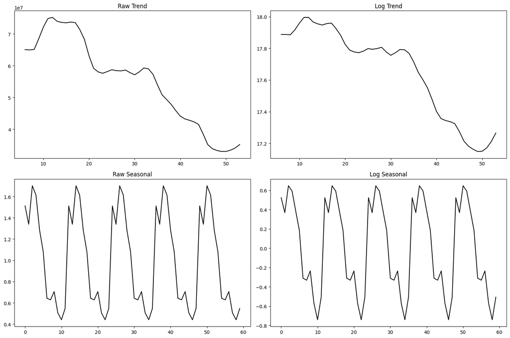

```python
decomp_raw = seasonal_decompose(data['Weight'], model='multiplicative', period=12)

data['Weight_log'] = np.log1p(data['Weight'])
decomp_log = seasonal_decompose(data['Weight_log'], model='additive', period=12)

fig, axes = plt.subplots(2, 2, figsize=(15, 10))

decomp_raw.trend.plot(ax=axes[0,0], color='black'); axes[0,0].set_title('Raw Trend')
decomp_log.trend.plot(ax=axes[0,1], color='black'); axes[0,1].set_title('Log Trend')
decomp_raw.seasonal.plot(ax=axes[1,0], color='black'); axes[1,0].set_title('Raw Seasonal')
decomp_log.seasonal.plot(ax=axes[1,1], color='black'); axes[1,1].set_title('Log Seasonal')

plt.tight_layout()
plt.show()
```

Run auto arima on log data (but set d's to have some boundaries based on observation of the data):

```python
sarima_log_auto = pm.auto_arima(np.log1p(data['Weight']),
                           start_p=0, start_q=0,
                           max_p=5, max_q=5, m=12,
                           start_P=0, seasonal=True,
                           d=1, D=1,
                           trace=True,
                           error_action='ignore',
                           suppress_warnings=True,
                           stepwise=False)
```

```
 ARIMA(0,1,0)(0,1,0)[12]             : AIC=53.203, Time=0.01 sec
 ARIMA(0,1,0)(0,1,1)[12]             : AIC=inf, Time=0.04 sec
 ARIMA(0,1,0)(0,1,2)[12]             : AIC=inf, Time=0.13 sec
 ARIMA(0,1,0)(1,1,0)[12]             : AIC=53.361, Time=0.02 sec
 ARIMA(0,1,0)(1,1,1)[12]             : AIC=inf, Time=0.09 sec
 ARIMA(0,1,0)(1,1,2)[12]             : AIC=inf, Time=0.30 sec
 ARIMA(0,1,0)(2,1,0)[12]             : AIC=42.788, Time=0.07 sec
 ARIMA(0,1,0)(2,1,1)[12]             : AIC=inf, Time=0.26 sec
 ARIMA(0,1,0)(2,1,2)[12]             : AIC=42.631, Time=0.20 sec
 ARIMA(0,1,1)(0,1,0)[12]             : AIC=49.652, Time=0.01 sec
 ARIMA(0,1,1)(0,1,1)[12]             : AIC=inf, Time=0.07 sec
 ARIMA(0,1,1)(0,1,2)[12]             : AIC=inf, Time=0.27 sec
 ARIMA(0,1,1)(1,1,0)[12]             : AIC=49.971, Time=0.03 sec
 ARIMA(0,1,1)(1,1,1)[12]             : AIC=inf, Time=0.11 sec
 ARIMA(0,1,1)(1,1,2)[12]             : AIC=inf, Time=0.26 sec
 ARIMA(0,1,1)(2,1,0)[12]             : AIC=41.387, Time=0.12 sec
 ARIMA(0,1,1)(2,1,1)[12]             : AIC=inf, Time=0.29 sec
 ARIMA(0,1,1)(2,1,2)[12]             : AIC=40.412, Time=0.43 sec
 ARIMA(0,1,2)(0,1,0)[12]             : AIC=50.687, Time=0.01 sec
 ARIMA(0,1,2)(0,1,1)[12]             : AIC=inf, Time=0.10 sec
 ARIMA(0,1,2)(0,1,2)[12]             : AIC=inf, Time=0.18 sec
 ARIMA(0,1,2)(1,1,0)[12]             : AIC=50.265, Time=0.03 sec
 ARIMA(0,1,2)(1,1,1)[12]             : AIC=inf, Time=0.20 sec
 ARIMA(0,1,2)(1,1,2)[12]             : AIC=inf, Time=0.14 sec
 ARIMA(0,1,2)(2,1,0)[12]             : AIC=42.050, Time=0.14 sec
 ARIMA(0,1,2)(2,1,1)[12]             : AIC=inf, Time=0.41 sec
 ARIMA(0,1,3)(0,1,0)[12]             : AIC=50.819, Time=0.03 sec
 ARIMA(0,1,3)(0,1,1)[12]             : AIC=inf, Time=0.23 sec
 ARIMA(0,1,3)(0,1,2)[12]             : AIC=inf, Time=0.61 sec
 ARIMA(0,1,3)(1,1,0)[12]             : AIC=50.793, Time=0.05 sec
 ARIMA(0,1,3)(1,1,1)[12]             : AIC=inf, Time=0.17 sec
 ARIMA(0,1,3)(2,1,0)[12]             : AIC=43.785, Time=0.22 sec
 ARIMA(0,1,4)(0,1,0)[12]             : AIC=inf, Time=0.10 sec
 ARIMA(0,1,4)(0,1,1)[12]             : AIC=inf, Time=0.26 sec
 ARIMA(0,1,4)(1,1,0)[12]             : AIC=inf, Time=0.23 sec
 ARIMA(0,1,5)(0,1,0)[12]             : AIC=inf, Time=0.11 sec
 ARIMA(1,1,0)(0,1,0)[12]             : AIC=50.840, Time=0.01 sec
 ARIMA(1,1,0)(0,1,1)[12]             : AIC=inf, Time=0.11 sec
 ARIMA(1,1,0)(0,1,2)[12]             : AIC=inf, Time=0.22 sec
 ARIMA(1,1,0)(1,1,0)[12]             : AIC=51.450, Time=0.02 sec
```

[output cut: 44 more lines]

```
 ARIMA(3,1,0)(1,1,0)[12]             : AIC=53.495, Time=0.03 sec
 ARIMA(3,1,0)(1,1,1)[12]             : AIC=inf, Time=0.18 sec
 ARIMA(3,1,0)(2,1,0)[12]             : AIC=44.831, Time=0.10 sec
 ARIMA(3,1,1)(0,1,0)[12]             : AIC=52.793, Time=0.03 sec
 ARIMA(3,1,1)(0,1,1)[12]             : AIC=inf, Time=0.20 sec
 ARIMA(3,1,1)(1,1,0)[12]             : AIC=52.657, Time=0.08 sec
 ARIMA(3,1,2)(0,1,0)[12]             : AIC=inf, Time=0.09 sec
 ARIMA(4,1,0)(0,1,0)[12]             : AIC=51.680, Time=0.01 sec
 ARIMA(4,1,0)(0,1,1)[12]             : AIC=inf, Time=0.25 sec
 ARIMA(4,1,0)(1,1,0)[12]             : AIC=51.126, Time=0.06 sec
 ARIMA(4,1,1)(0,1,0)[12]             : AIC=53.524, Time=0.03 sec
 ARIMA(5,1,0)(0,1,0)[12]             : AIC=53.380, Time=0.02 sec

Best model:  ARIMA(0,1,1)(2,1,2)[12]
Total fit time: 17.021 seconds
```

```python
print('order: ',sarima_log_auto.order)
print('seasonal order: ',sarima_log_auto.seasonal_order)
```

```
order:  (0, 1, 1)
seasonal order:  (2, 1, 2, 12)
```

```python
horizon = 3
log_auto_results = []

for cutoff in range(44, 60):
    if cutoff + horizon >= len(data):
        break

    train = data.iloc[:cutoff+1]

    sarima_log_auto_model = sm.tsa.SARIMAX(
        np.log1p(train['Weight']),
        order=sarima_log_auto.order,
        seasonal_order=sarima_log_auto.seasonal_order,
        trend='c',
        use_exact_diffuse=True
    ).fit(disp=False)

    yhat = np.expm1(sarima_log_auto_model.forecast(steps=horizon))
    y_true = data['Weight'].iloc[cutoff+1: cutoff+1 + horizon]

    for h in range(horizon):
        ae = abs(yhat.iloc[h] - y_true.iloc[h])
        ape = ae / max(abs(y_true.iloc[h]), 1e-8)

        log_auto_results.append({
            'cutoff': cutoff,
            'horizon': h + 1,
            'cutoff_month': data['Import Date'].iloc[cutoff].to_period('M').to_timestamp(),
            'month': data['Import Date'].iloc[cutoff + h + 1].to_period('M').to_timestamp(),
            'y': y_true.iloc[h],
            'yhat': yhat.iloc[h],
            'AE': ae,
            'APE': ape
        })

sarima_log_auto_cv_df = pd.DataFrame(log_auto_results)
sarima_log_auto_cv_df.style.format({
    'cutoff_month': '{:%m-%d-%Y}',
    'month': '{:%m-%d-%Y}',
    'y': '{:,.0f}',
    'yhat': '{:,.0f}',
    'AE': '{:,.0f}',
    'APE': '{:.0%}'
})
```

|  | cutoff | horizon | cutoff_month | month | y | yhat | AE | APE |
| --- | --- | --- | --- | --- | --- | --- | --- | --- |
| 0 | 44 | 1 | 09-01-2023 | 10-01-2023 | 15,172,388 | 18,132,359 | 2,959,971 | 20% |
| 1 | 44 | 2 | 09-01-2023 | 11-01-2023 | 11,741,002 | 11,188,104 | 552,898 | 5% |
| 2 | 44 | 3 | 09-01-2023 | 12-01-2023 | 17,305,596 | 15,839,031 | 1,466,565 | 8% |
| 3 | 45 | 1 | 10-01-2023 | 11-01-2023 | 11,741,002 | 10,024,694 | 1,716,308 | 15% |
| 4 | 45 | 2 | 10-01-2023 | 12-01-2023 | 17,305,596 | 14,694,612 | 2,610,984 | 15% |
| 5 | 45 | 3 | 10-01-2023 | 01-01-2024 | 64,702,033 | 33,970,825 | 30,731,208 | 47% |
| 6 | 46 | 1 | 11-01-2023 | 12-01-2023 | 17,305,596 | 16,423,567 | 882,029 | 5% |
| 7 | 46 | 2 | 11-01-2023 | 01-01-2024 | 64,702,033 | 37,164,728 | 27,537,305 | 43% |
| 8 | 46 | 3 | 11-01-2023 | 02-01-2024 | 65,375,575 | 32,163,379 | 33,212,196 | 51% |
| 9 | 47 | 1 | 12-01-2023 | 01-01-2024 | 64,702,033 | 38,181,643 | 26,520,390 | 41% |
| 10 | 47 | 2 | 12-01-2023 | 02-01-2024 | 65,375,575 | 32,519,650 | 32,855,925 | 50% |
| 11 | 47 | 3 | 12-01-2023 | 03-01-2024 | 62,364,919 | 44,945,535 | 17,419,384 | 28% |
| 12 | 48 | 1 | 01-01-2024 | 02-01-2024 | 65,375,575 | 36,089,098 | 29,286,477 | 45% |
| 13 | 48 | 2 | 01-01-2024 | 03-01-2024 | 62,364,919 | 51,142,539 | 11,222,380 | 18% |
| 14 | 48 | 3 | 01-01-2024 | 04-01-2024 | 34,933,233 | 42,249,976 | 7,316,743 | 21% |
| 15 | 49 | 1 | 02-01-2024 | 03-01-2024 | 62,364,919 | 69,450,790 | 7,085,871 | 11% |
| 16 | 49 | 2 | 02-01-2024 | 04-01-2024 | 34,933,233 | 46,086,651 | 11,153,418 | 32% |
| 17 | 49 | 3 | 02-01-2024 | 05-01-2024 | 35,504,037 | 34,536,974 | 967,063 | 3% |
| 18 | 50 | 1 | 03-01-2024 | 04-01-2024 | 34,933,233 | 42,693,625 | 7,760,392 | 22% |
| 19 | 50 | 2 | 03-01-2024 | 05-01-2024 | 35,504,037 | 31,879,381 | 3,624,656 | 10% |
| 20 | 50 | 3 | 03-01-2024 | 06-01-2024 | 26,935,635 | 27,200,542 | 264,907 | 1% |
| 21 | 51 | 1 | 04-01-2024 | 05-01-2024 | 35,504,037 | 29,412,610 | 6,091,427 | 17% |
| 22 | 51 | 2 | 04-01-2024 | 06-01-2024 | 26,935,635 | 26,180,885 | 754,750 | 3% |
| 23 | 51 | 3 | 04-01-2024 | 07-01-2024 | 19,175,494 | 14,965,298 | 4,210,196 | 22% |
| 24 | 52 | 1 | 05-01-2024 | 06-01-2024 | 26,935,635 | 27,846,940 | 911,305 | 3% |
| 25 | 52 | 2 | 05-01-2024 | 07-01-2024 | 19,175,494 | 15,837,472 | 3,338,022 | 17% |
| 26 | 52 | 3 | 05-01-2024 | 08-01-2024 | 21,449,146 | 13,438,783 | 8,010,363 | 37% |
| 27 | 53 | 1 | 06-01-2024 | 07-01-2024 | 19,175,494 | 15,710,658 | 3,464,836 | 18% |
| 28 | 53 | 2 | 06-01-2024 | 08-01-2024 | 21,449,146 | 13,269,210 | 8,179,936 | 38% |
| 29 | 53 | 3 | 06-01-2024 | 09-01-2024 | 23,828,291 | 17,104,520 | 6,723,771 | 28% |
| 30 | 54 | 1 | 07-01-2024 | 08-01-2024 | 21,449,146 | 13,818,446 | 7,630,700 | 36% |
| 31 | 54 | 2 | 07-01-2024 | 09-01-2024 | 23,828,291 | 18,154,813 | 5,673,478 | 24% |
| 32 | 54 | 3 | 07-01-2024 | 10-01-2024 | 20,121,692 | 9,713,765 | 10,407,927 | 52% |
| 33 | 55 | 1 | 08-01-2024 | 09-01-2024 | 23,828,291 | 19,020,992 | 4,807,299 | 20% |
| 34 | 55 | 2 | 08-01-2024 | 10-01-2024 | 20,121,692 | 10,760,367 | 9,361,325 | 47% |
| 35 | 55 | 3 | 08-01-2024 | 11-01-2024 | 23,311,088 | 9,080,584 | 14,230,504 | 61% |
| 36 | 56 | 1 | 09-01-2024 | 10-01-2024 | 20,121,692 | 12,840,900 | 7,280,792 | 36% |
| 37 | 56 | 2 | 09-01-2024 | 11-01-2024 | 23,311,088 | 10,562,908 | 12,748,180 | 55% |
| 38 | 56 | 3 | 09-01-2024 | 12-01-2024 | 31,759,202 | 17,556,889 | 14,202,313 | 45% |

```python
sarima_log_auto_cv = sarima_log_auto_cv_df.groupby('horizon').agg(
    MAE=('AE', 'mean'),
    MAPE=('APE', 'mean'))

sarima_log_auto_cv.style.format({
    'MAE': '{:,.0f}',
    'MAPE': '{:.0%}'})
```

| horizon | MAE | MAPE |
| --- | --- | --- |
| 1 | 8,184,446 | 22% |
| 2 | 9,970,251 | 27% |
| 3 | 11,474,088 | 31% |

Performance improved significantly to the same overall MAPE as the best performing Triple Exponential Smoothing model from earlier:

```python
sarima_log_auto_overall_MAE  = sarima_log_auto_cv_df['AE'].mean()
sarima_log_auto_overall_MAPE = sarima_log_auto_cv_df['APE'].mean()

print(f"MAE: {sarima_log_auto_overall_MAE:,.0f}")
print(f"MAPE: {sarima_log_auto_overall_MAPE:.0%}")
```

```
MAE: 9,876,261
MAPE: 27%
```

Full flexible auto arima - not setting anything (not setting d's):

```python
sarima_log_full_flex = pm.auto_arima(np.log1p(data['Weight']),
                           start_p=0, start_q=0,
                           max_p=5, max_q=5, m=12,
                           start_P=0, seasonal=True,
                           trace=True,
                           error_action='ignore',
                           suppress_warnings=True,
                           stepwise=False)
```

```
 ARIMA(0,1,0)(0,0,0)[12] intercept   : AIC=74.720, Time=0.01 sec
 ARIMA(0,1,0)(0,0,1)[12] intercept   : AIC=58.069, Time=0.02 sec
 ARIMA(0,1,0)(0,0,2)[12] intercept   : AIC=60.069, Time=0.07 sec
 ARIMA(0,1,0)(1,0,0)[12] intercept   : AIC=59.645, Time=0.02 sec
 ARIMA(0,1,0)(1,0,1)[12] intercept   : AIC=inf, Time=0.13 sec
 ARIMA(0,1,0)(1,0,2)[12] intercept   : AIC=inf, Time=0.21 sec
 ARIMA(0,1,0)(2,0,0)[12] intercept   : AIC=61.620, Time=0.06 sec
 ARIMA(0,1,0)(2,0,1)[12] intercept   : AIC=inf, Time=0.11 sec
 ARIMA(0,1,0)(2,0,2)[12] intercept   : AIC=inf, Time=0.23 sec
 ARIMA(0,1,1)(0,0,0)[12] intercept   : AIC=76.596, Time=0.01 sec
 ARIMA(0,1,1)(0,0,1)[12] intercept   : AIC=59.177, Time=0.03 sec
 ARIMA(0,1,1)(0,0,2)[12] intercept   : AIC=61.165, Time=0.07 sec
 ARIMA(0,1,1)(1,0,0)[12] intercept   : AIC=59.840, Time=0.03 sec
 ARIMA(0,1,1)(1,0,1)[12] intercept   : AIC=inf, Time=0.15 sec
 ARIMA(0,1,1)(1,0,2)[12] intercept   : AIC=inf, Time=0.28 sec
 ARIMA(0,1,1)(2,0,0)[12] intercept   : AIC=61.839, Time=0.06 sec
 ARIMA(0,1,1)(2,0,1)[12] intercept   : AIC=60.055, Time=0.16 sec
 ARIMA(0,1,1)(2,0,2)[12] intercept   : AIC=inf, Time=0.30 sec
 ARIMA(0,1,2)(0,0,0)[12] intercept   : AIC=78.331, Time=0.01 sec
 ARIMA(0,1,2)(0,0,1)[12] intercept   : AIC=60.751, Time=0.04 sec
 ARIMA(0,1,2)(0,0,2)[12] intercept   : AIC=62.720, Time=0.09 sec
 ARIMA(0,1,2)(1,0,0)[12] intercept   : AIC=inf, Time=0.10 sec
 ARIMA(0,1,2)(1,0,1)[12] intercept   : AIC=inf, Time=0.12 sec
 ARIMA(0,1,2)(1,0,2)[12] intercept   : AIC=inf, Time=0.33 sec
 ARIMA(0,1,2)(2,0,0)[12] intercept   : AIC=inf, Time=0.24 sec
 ARIMA(0,1,2)(2,0,1)[12] intercept   : AIC=inf, Time=0.29 sec
 ARIMA(0,1,3)(0,0,0)[12] intercept   : AIC=inf, Time=0.07 sec
 ARIMA(0,1,3)(0,0,1)[12] intercept   : AIC=inf, Time=0.12 sec
 ARIMA(0,1,3)(0,0,2)[12] intercept   : AIC=inf, Time=0.23 sec
 ARIMA(0,1,3)(1,0,0)[12] intercept   : AIC=inf, Time=0.11 sec
 ARIMA(0,1,3)(1,0,1)[12] intercept   : AIC=inf, Time=0.16 sec
 ARIMA(0,1,3)(2,0,0)[12] intercept   : AIC=inf, Time=0.31 sec
 ARIMA(0,1,4)(0,0,0)[12] intercept   : AIC=inf, Time=0.04 sec
 ARIMA(0,1,4)(0,0,1)[12] intercept   : AIC=inf, Time=0.13 sec
 ARIMA(0,1,4)(1,0,0)[12] intercept   : AIC=inf, Time=0.15 sec
 ARIMA(0,1,5)(0,0,0)[12] intercept   : AIC=inf, Time=0.06 sec
 ARIMA(1,1,0)(0,0,0)[12] intercept   : AIC=76.610, Time=0.01 sec
 ARIMA(1,1,0)(0,0,1)[12] intercept   : AIC=59.273, Time=0.03 sec
 ARIMA(1,1,0)(0,0,2)[12] intercept   : AIC=61.265, Time=0.06 sec
 ARIMA(1,1,0)(1,0,0)[12] intercept   : AIC=60.149, Time=0.02 sec
```

[output cut: 44 more lines]

```
 ARIMA(3,1,0)(1,0,0)[12] intercept   : AIC=62.851, Time=0.05 sec
 ARIMA(3,1,0)(1,0,1)[12] intercept   : AIC=inf, Time=0.16 sec
 ARIMA(3,1,0)(2,0,0)[12] intercept   : AIC=64.851, Time=0.12 sec
 ARIMA(3,1,1)(0,0,0)[12] intercept   : AIC=inf, Time=0.05 sec
 ARIMA(3,1,1)(0,0,1)[12] intercept   : AIC=inf, Time=0.17 sec
 ARIMA(3,1,1)(1,0,0)[12] intercept   : AIC=inf, Time=0.12 sec
 ARIMA(3,1,2)(0,0,0)[12] intercept   : AIC=inf, Time=0.04 sec
 ARIMA(4,1,0)(0,0,0)[12] intercept   : AIC=81.534, Time=0.01 sec
 ARIMA(4,1,0)(0,0,1)[12] intercept   : AIC=63.438, Time=0.05 sec
 ARIMA(4,1,0)(1,0,0)[12] intercept   : AIC=62.527, Time=0.12 sec
 ARIMA(4,1,1)(0,0,0)[12] intercept   : AIC=inf, Time=0.08 sec
 ARIMA(5,1,0)(0,0,0)[12] intercept   : AIC=82.538, Time=0.02 sec

Best model:  ARIMA(1,1,1)(1,0,1)[12] intercept
Total fit time: 11.417 seconds
```

```python
print('order: ',sarima_log_full_flex.order)
print('seasonal order: ',sarima_log_full_flex.seasonal_order)
```

```
order:  (1, 1, 1)
seasonal order:  (1, 0, 1, 12)
```

```python
horizon = 3
log_full_flex_results = []

for cutoff in range(44, 60):
    if cutoff + horizon >= len(data):
        break

    train = data.iloc[:cutoff+1]

    sarima_log_full_flex_model = sm.tsa.SARIMAX(
        np.log1p(train['Weight']),
        order=sarima_log_full_flex.order,
        seasonal_order=sarima_log_full_flex.seasonal_order,
        trend='c',
        use_exact_diffuse=True
    ).fit(disp=False)

    yhat = np.expm1(sarima_log_full_flex_model.forecast(steps=horizon))
    y_true = data['Weight'].iloc[cutoff+1: cutoff+1 + horizon]

    for h in range(horizon):
        ae = abs(yhat.iloc[h] - y_true.iloc[h])
        ape = ae / max(abs(y_true.iloc[h]), 1e-8)

        log_full_flex_results.append({
            'cutoff': cutoff,
            'horizon': h + 1,
            'cutoff_month': data['Import Date'].iloc[cutoff].to_period('M').to_timestamp(),
            'month': data['Import Date'].iloc[cutoff + h + 1].to_period('M').to_timestamp(),
            'y': y_true.iloc[h],
            'yhat': yhat.iloc[h],
            'AE': ae,
            'APE': ape
        })

sarima_log_full_flex_cv_df = pd.DataFrame(log_full_flex_results)
sarima_log_full_flex_cv_df.style.format({
    'cutoff_month': '{:%m-%d-%Y}',
    'month': '{:%m-%d-%Y}',
    'y': '{:,.0f}',
    'yhat': '{:,.0f}',
    'AE': '{:,.0f}',
    'APE': '{:.0%}'
})
```

|  | cutoff | horizon | cutoff_month | month | y | yhat | AE | APE |
| --- | --- | --- | --- | --- | --- | --- | --- | --- |
| 0 | 44 | 1 | 09-01-2023 | 10-01-2023 | 15,172,388 | 19,022,105 | 3,849,717 | 25% |
| 1 | 44 | 2 | 09-01-2023 | 11-01-2023 | 11,741,002 | 16,374,058 | 4,633,056 | 39% |
| 2 | 44 | 3 | 09-01-2023 | 12-01-2023 | 17,305,596 | 13,644,569 | 3,661,027 | 21% |
| 3 | 45 | 1 | 10-01-2023 | 11-01-2023 | 11,741,002 | 17,196,917 | 5,455,915 | 46% |
| 4 | 45 | 2 | 10-01-2023 | 12-01-2023 | 17,305,596 | 21,634,850 | 4,329,254 | 25% |
| 5 | 45 | 3 | 10-01-2023 | 01-01-2024 | 64,702,033 | 45,512,077 | 19,189,956 | 30% |
| 6 | 46 | 1 | 11-01-2023 | 12-01-2023 | 17,305,596 | 17,042,136 | 263,460 | 2% |
| 7 | 46 | 2 | 11-01-2023 | 01-01-2024 | 64,702,033 | 38,918,497 | 25,783,536 | 40% |
| 8 | 46 | 3 | 11-01-2023 | 02-01-2024 | 65,375,575 | 39,278,741 | 26,096,834 | 40% |
| 9 | 47 | 1 | 12-01-2023 | 01-01-2024 | 64,702,033 | 39,207,900 | 25,494,133 | 39% |
| 10 | 47 | 2 | 12-01-2023 | 02-01-2024 | 65,375,575 | 39,392,927 | 25,982,648 | 40% |
| 11 | 47 | 3 | 12-01-2023 | 03-01-2024 | 62,364,919 | 50,918,681 | 11,446,238 | 18% |
| 12 | 48 | 1 | 01-01-2024 | 02-01-2024 | 65,375,575 | 53,263,101 | 12,112,474 | 19% |
| 13 | 48 | 2 | 01-01-2024 | 03-01-2024 | 62,364,919 | 62,239,477 | 125,442 | 0% |
| 14 | 48 | 3 | 01-01-2024 | 04-01-2024 | 34,933,233 | 60,362,747 | 25,429,514 | 73% |
| 15 | 49 | 1 | 02-01-2024 | 03-01-2024 | 62,364,919 | 70,718,057 | 8,353,138 | 13% |
| 16 | 49 | 2 | 02-01-2024 | 04-01-2024 | 34,933,233 | 65,343,812 | 30,410,579 | 87% |
| 17 | 49 | 3 | 02-01-2024 | 05-01-2024 | 35,504,037 | 49,088,781 | 13,584,744 | 38% |
| 18 | 50 | 1 | 03-01-2024 | 04-01-2024 | 34,933,233 | 61,667,036 | 26,733,803 | 77% |
| 19 | 50 | 2 | 03-01-2024 | 05-01-2024 | 35,504,037 | 47,266,024 | 11,761,987 | 33% |
| 20 | 50 | 3 | 03-01-2024 | 06-01-2024 | 26,935,635 | 41,055,774 | 14,120,139 | 52% |
| 21 | 51 | 1 | 04-01-2024 | 05-01-2024 | 35,504,037 | 29,688,032 | 5,816,005 | 16% |
| 22 | 51 | 2 | 04-01-2024 | 06-01-2024 | 26,935,635 | 22,949,698 | 3,985,937 | 15% |
| 23 | 51 | 3 | 04-01-2024 | 07-01-2024 | 19,175,494 | 18,947,987 | 227,507 | 1% |
| 24 | 52 | 1 | 05-01-2024 | 06-01-2024 | 26,935,635 | 24,509,724 | 2,425,911 | 9% |
| 25 | 52 | 2 | 05-01-2024 | 07-01-2024 | 19,175,494 | 20,206,939 | 1,031,445 | 5% |
| 26 | 52 | 3 | 05-01-2024 | 08-01-2024 | 21,449,146 | 24,359,621 | 2,910,475 | 14% |
| 27 | 53 | 1 | 06-01-2024 | 07-01-2024 | 19,175,494 | 19,586,924 | 411,430 | 2% |
| 28 | 53 | 2 | 06-01-2024 | 08-01-2024 | 21,449,146 | 21,227,726 | 221,420 | 1% |
| 29 | 53 | 3 | 06-01-2024 | 09-01-2024 | 23,828,291 | 21,642,176 | 2,186,115 | 9% |
| 30 | 54 | 1 | 07-01-2024 | 08-01-2024 | 21,449,146 | 20,717,126 | 732,020 | 3% |
| 31 | 54 | 2 | 07-01-2024 | 09-01-2024 | 23,828,291 | 20,584,375 | 3,243,916 | 14% |
| 32 | 54 | 3 | 07-01-2024 | 10-01-2024 | 20,121,692 | 16,798,862 | 3,322,830 | 17% |
| 33 | 55 | 1 | 08-01-2024 | 09-01-2024 | 23,828,291 | 20,391,635 | 3,436,656 | 14% |
| 34 | 55 | 2 | 08-01-2024 | 10-01-2024 | 20,121,692 | 16,740,644 | 3,381,048 | 17% |
| 35 | 55 | 3 | 08-01-2024 | 11-01-2024 | 23,311,088 | 14,168,457 | 9,142,631 | 39% |
| 36 | 56 | 1 | 09-01-2024 | 10-01-2024 | 20,121,692 | 18,667,555 | 1,454,137 | 7% |
| 37 | 56 | 2 | 09-01-2024 | 11-01-2024 | 23,311,088 | 15,944,377 | 7,366,711 | 32% |
| 38 | 56 | 3 | 09-01-2024 | 12-01-2024 | 31,759,202 | 18,232,002 | 13,527,200 | 43% |

```python
sarima_log_full_flex_cv = sarima_log_full_flex_cv_df.groupby('horizon').agg(
    MAE=('AE', 'mean'),
    MAPE=('APE', 'mean'))

sarima_log_full_flex_cv.style.format({
    'MAE': '{:,.0f}',
    'MAPE': '{:.0%}'})
```

| horizon | MAE | MAPE |
| --- | --- | --- |
| 1 | 7,426,062 | 21% |
| 2 | 9,404,383 | 27% |
| 3 | 11,141,939 | 30% |

```python
sarima_log_full_flex_overall_MAE  = sarima_log_full_flex_cv_df['AE'].mean()
sarima_log_full_flex_overall_MAPE = sarima_log_full_flex_cv_df['APE'].mean()

print(f"MAE: {sarima_log_full_flex_overall_MAE:,.0f}")
print(f"MAPE (%): {sarima_log_full_flex_overall_MAPE:.0%}")
```

```
MAE: 9,324,128
MAPE (%): 26%
```

Switch to manual model:

Ideal with log (based on autocorrelation plots earlier + decomposition):

```python
sarima_log_manual_order = (2,1,1)
sarima_log_manual_seasonal_order = (1,1,1,12)
```

```python
horizon = 3
log_manual_results = []

for cutoff in range(44, 60):
    if cutoff + horizon >= len(data):
        break

    train = data.iloc[:cutoff+1]

    sarima_log_manual_model = sm.tsa.SARIMAX(
        np.log1p(train['Weight']),
        order=sarima_log_manual_order,
        seasonal_order=sarima_log_manual_seasonal_order,
        trend='c',
        use_exact_diffuse=True
    ).fit(disp=False)

    yhat = np.expm1(sarima_log_manual_model.forecast(steps=horizon))
    y_true = data['Weight'].iloc[cutoff+1: cutoff+1 + horizon]

    for h in range(horizon):
        ae = abs(yhat.iloc[h] - y_true.iloc[h])
        ape = ae / max(abs(y_true.iloc[h]), 1e-8)

        log_manual_results.append({
            'cutoff': cutoff,
            'horizon': h + 1,
            'cutoff_month': data['Import Date'].iloc[cutoff].to_period('M').to_timestamp(),
            'month': data['Import Date'].iloc[cutoff + h + 1].to_period('M').to_timestamp(),
            'y': y_true.iloc[h],
            'yhat': yhat.iloc[h],
            'AE': ae,
            'APE': ape

        })

sarima_log_manual_cv_df = pd.DataFrame(log_manual_results)
sarima_log_manual_cv_df.style.format({
    'cutoff_month': '{:%m-%d-%Y}',
    'month': '{:%m-%d-%Y}',
    'y': '{:,.0f}',
    'yhat': '{:,.0f}',
    'AE': '{:,.0f}',
    'APE': '{:.0%}'
})
```

|  | cutoff | horizon | cutoff_month | month | y | yhat | AE | APE |
| --- | --- | --- | --- | --- | --- | --- | --- | --- |
| 0 | 44 | 1 | 09-01-2023 | 10-01-2023 | 15,172,388 | 17,533,105 | 2,360,717 | 16% |
| 1 | 44 | 2 | 09-01-2023 | 11-01-2023 | 11,741,002 | 14,875,708 | 3,134,706 | 27% |
| 2 | 44 | 3 | 09-01-2023 | 12-01-2023 | 17,305,596 | 15,784,007 | 1,521,589 | 9% |
| 3 | 45 | 1 | 10-01-2023 | 11-01-2023 | 11,741,002 | 14,100,880 | 2,359,878 | 20% |
| 4 | 45 | 2 | 10-01-2023 | 12-01-2023 | 17,305,596 | 15,694,067 | 1,611,529 | 9% |
| 5 | 45 | 3 | 10-01-2023 | 01-01-2024 | 64,702,033 | 38,782,641 | 25,919,392 | 40% |
| 6 | 46 | 1 | 11-01-2023 | 12-01-2023 | 17,305,596 | 14,413,347 | 2,892,249 | 17% |
| 7 | 46 | 2 | 11-01-2023 | 01-01-2024 | 64,702,033 | 37,130,369 | 27,571,664 | 43% |
| 8 | 46 | 3 | 11-01-2023 | 02-01-2024 | 65,375,575 | 33,732,957 | 31,642,618 | 48% |
| 9 | 47 | 1 | 12-01-2023 | 01-01-2024 | 64,702,033 | 39,630,134 | 25,071,899 | 39% |
| 10 | 47 | 2 | 12-01-2023 | 02-01-2024 | 65,375,575 | 34,422,739 | 30,952,836 | 47% |
| 11 | 47 | 3 | 12-01-2023 | 03-01-2024 | 62,364,919 | 42,204,836 | 20,160,083 | 32% |
| 12 | 48 | 1 | 01-01-2024 | 02-01-2024 | 65,375,575 | 43,141,021 | 22,234,554 | 34% |
| 13 | 48 | 2 | 01-01-2024 | 03-01-2024 | 62,364,919 | 46,246,949 | 16,117,970 | 26% |
| 14 | 48 | 3 | 01-01-2024 | 04-01-2024 | 34,933,233 | 42,942,172 | 8,008,939 | 23% |
| 15 | 49 | 1 | 02-01-2024 | 03-01-2024 | 62,364,919 | 57,197,381 | 5,167,538 | 8% |
| 16 | 49 | 2 | 02-01-2024 | 04-01-2024 | 34,933,233 | 48,828,376 | 13,895,143 | 40% |
| 17 | 49 | 3 | 02-01-2024 | 05-01-2024 | 35,504,037 | 33,518,250 | 1,985,787 | 6% |
| 18 | 50 | 1 | 03-01-2024 | 04-01-2024 | 34,933,233 | 51,099,745 | 16,166,512 | 46% |
| 19 | 50 | 2 | 03-01-2024 | 05-01-2024 | 35,504,037 | 34,455,289 | 1,048,748 | 3% |
| 20 | 50 | 3 | 03-01-2024 | 06-01-2024 | 26,935,635 | 27,590,976 | 655,341 | 2% |
| 21 | 51 | 1 | 04-01-2024 | 05-01-2024 | 35,504,037 | 28,543,211 | 6,960,826 | 20% |
| 22 | 51 | 2 | 04-01-2024 | 06-01-2024 | 26,935,635 | 26,164,625 | 771,010 | 3% |
| 23 | 51 | 3 | 04-01-2024 | 07-01-2024 | 19,175,494 | 14,860,194 | 4,315,300 | 23% |
| 24 | 52 | 1 | 05-01-2024 | 06-01-2024 | 26,935,635 | 29,343,558 | 2,407,923 | 9% |
| 25 | 52 | 2 | 05-01-2024 | 07-01-2024 | 19,175,494 | 15,632,127 | 3,543,367 | 18% |
| 26 | 52 | 3 | 05-01-2024 | 08-01-2024 | 21,449,146 | 14,745,230 | 6,703,916 | 31% |
| 27 | 53 | 1 | 06-01-2024 | 07-01-2024 | 19,175,494 | 15,005,852 | 4,169,642 | 22% |
| 28 | 53 | 2 | 06-01-2024 | 08-01-2024 | 21,449,146 | 14,511,456 | 6,937,690 | 32% |
| 29 | 53 | 3 | 06-01-2024 | 09-01-2024 | 23,828,291 | 14,480,263 | 9,348,028 | 39% |
| 30 | 54 | 1 | 07-01-2024 | 08-01-2024 | 21,449,146 | 16,223,817 | 5,225,329 | 24% |
| 31 | 54 | 2 | 07-01-2024 | 09-01-2024 | 23,828,291 | 15,324,391 | 8,503,900 | 36% |
| 32 | 54 | 3 | 07-01-2024 | 10-01-2024 | 20,121,692 | 10,494,907 | 9,626,785 | 48% |
| 33 | 55 | 1 | 08-01-2024 | 09-01-2024 | 23,828,291 | 17,382,719 | 6,445,572 | 27% |
| 34 | 55 | 2 | 08-01-2024 | 10-01-2024 | 20,121,692 | 11,062,373 | 9,059,319 | 45% |
| 35 | 55 | 3 | 08-01-2024 | 11-01-2024 | 23,311,088 | 8,674,143 | 14,636,945 | 63% |
| 36 | 56 | 1 | 09-01-2024 | 10-01-2024 | 20,121,692 | 12,957,528 | 7,164,164 | 36% |
| 37 | 56 | 2 | 09-01-2024 | 11-01-2024 | 23,311,088 | 9,499,250 | 13,811,838 | 59% |
| 38 | 56 | 3 | 09-01-2024 | 12-01-2024 | 31,759,202 | 11,324,074 | 20,435,128 | 64% |

```python
sarima_log_manual_cv = sarima_log_manual_cv_df.groupby('horizon').agg(
    MAE=('AE', 'mean'),
    MAPE=('APE', 'mean'))

sarima_log_manual_cv.style.format({
    'MAE': '{:,.0f}',
    'MAPE': '{:.0%}'})
```

| horizon | MAE | MAPE |
| --- | --- | --- |
| 1 | 8,355,908 | 24% |
| 2 | 10,535,363 | 30% |
| 3 | 11,919,988 | 33% |

Performance is still looking better, although still higher than the 27% from other models:

```python
sarima_log_manual_overall_MAE  = sarima_log_manual_cv_df['AE'].mean()
sarima_log_manual_overall_MAPE = sarima_log_manual_cv_df['APE'].mean()

print(f"MAE: {sarima_log_manual_overall_MAE:,.0f}")
print(f"MAPE (%): {sarima_log_manual_overall_MAPE:.0%}")
```

```
MAE: 10,270,420
MAPE (%): 29%
```

```python
final_order = sarima_log_auto_model.model.order
final_seasonal_order = sarima_log_auto_model.model.seasonal_order
```

```python
print(final_order)
print(final_seasonal_order)
```

```
(0, 1, 1)
(2, 1, 2, 12)
```

```python
sarima_final_cv = sarima_log_auto_cv
```

```python
sarima_final_cv.style.format({
    'MAE': '{:,.0f}',
    'MAPE': '{:.0%}'})
```

| horizon | MAE | MAPE |
| --- | --- | --- |
| 1 | 8,184,446 | 22% |
| 2 | 9,970,251 | 27% |
| 3 | 11,474,088 | 31% |

```python
sarima_final_overall_MAE = sarima_log_auto_overall_MAE
sarima_final_overall_MAPE = sarima_log_auto_overall_MAPE
```